# Data Analysis_HB_11052016

## Graphs in order to see potential interactions (CHANGE TO BOXPLOTS)

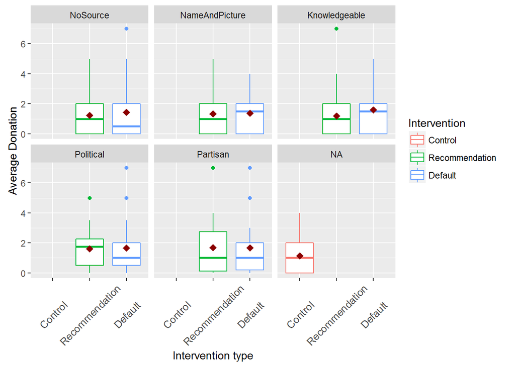

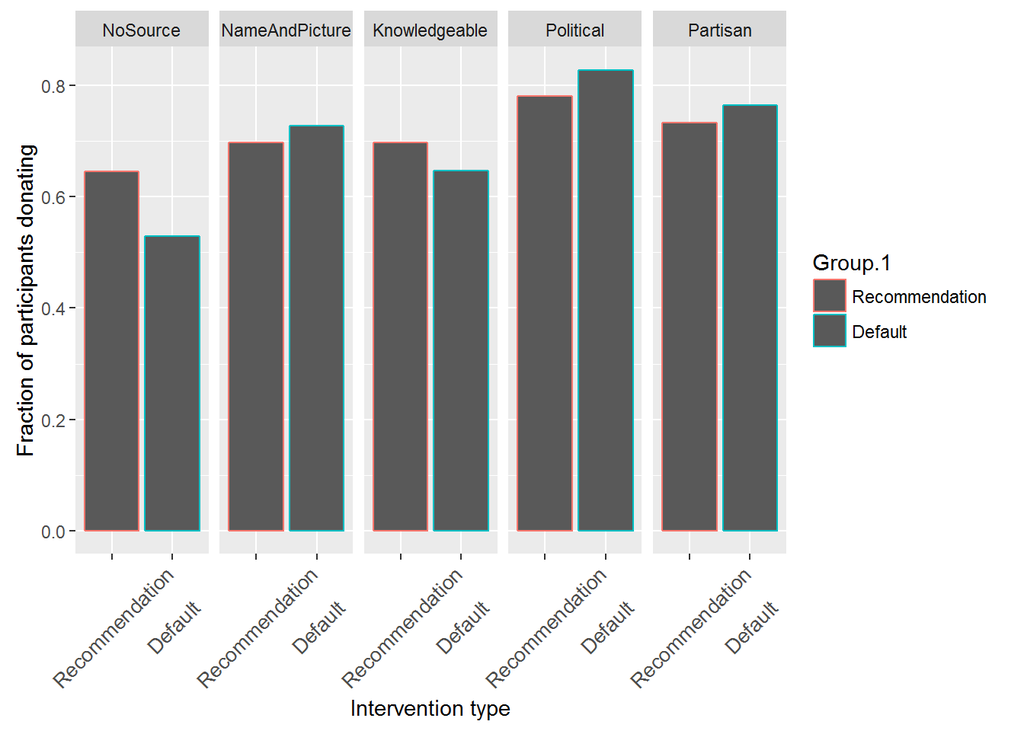

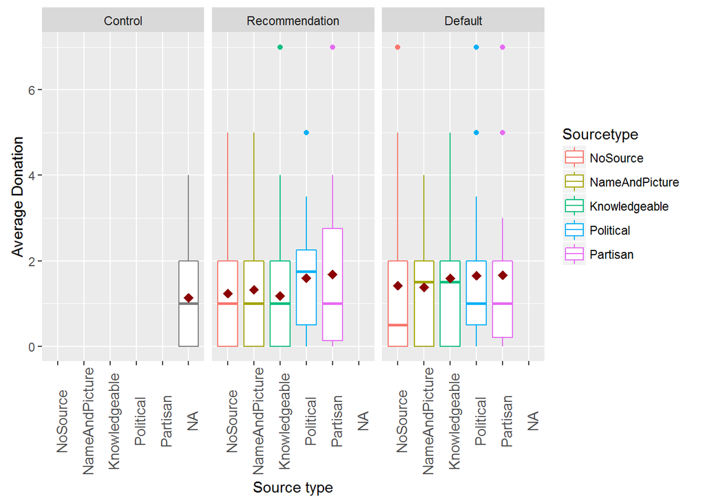

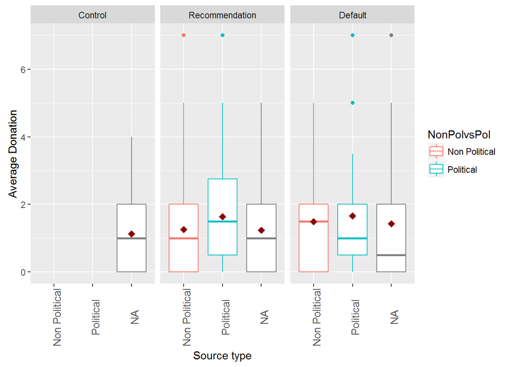

```
## group: Non Political
##   vars   n mean   sd median trimmed  mad min max range skew kurtosis   se
## 1    1 133 1.37 1.41      1    1.16 1.48   0   7     7 1.15     1.35 0.12
## --------------------------------------------------------
## group: Political
##   vars   n mean   sd median trimmed  mad min max range skew kurtosis   se
## 1    1 125 1.65 1.62      1     1.4 1.48   0   7     7 1.36     1.93 0.15
```

```
##
##  Wilcoxon rank sum test with continuity correction
##
## data:  df$Donation by df$NonPolvsPol
## W = 7533, p-value = 0.1848
## alternative hypothesis: true location shift is not equal to 0
```

```
##
##  Wilcoxon rank sum test with continuity correction
##
## data:  df$Donation[df$Intervention == "Recommendation"] by df$NonPolvsPol[df$Intervention == "Recommendation"]
## W = 1710.5, p-value = 0.103
## alternative hypothesis: true location shift is not equal to 0
```

```
##
## Call:
## lm(formula = Donation ~ NonPolvsPol * Intervention, data = df)
##
## Residuals:
##    Min     1Q Median     3Q    Max
## -1.660 -1.253 -0.253  0.747  5.747
##
## Coefficients:
##                                          Estimate Std. Error t value
## (Intercept)                                1.2530     0.1874   6.688
## NonPolvsPolPolitical                       0.3873     0.2692   1.439
## InterventionDefault                        0.2335     0.2640   0.885
## NonPolvsPolPolitical:InterventionDefault  -0.2135     0.3793  -0.563
##                                          Pr(>|t|)
## (Intercept)                              1.43e-10 ***
## NonPolvsPolPolitical                        0.151
## InterventionDefault                         0.377
## NonPolvsPolPolitical:InterventionDefault    0.574
## ---
## Signif. codes:  0 '***' 0.001 '**' 0.01 '*' 0.05 '.' 0.1 ' ' 1
##
## Residual standard error: 1.522 on 254 degrees of freedom
##   (96 observations deleted due to missingness)
## Multiple R-squared:  0.01154,    Adjusted R-squared:  -0.0001395
## F-statistic: 0.9881 on 3 and 254 DF,  p-value: 0.399
```

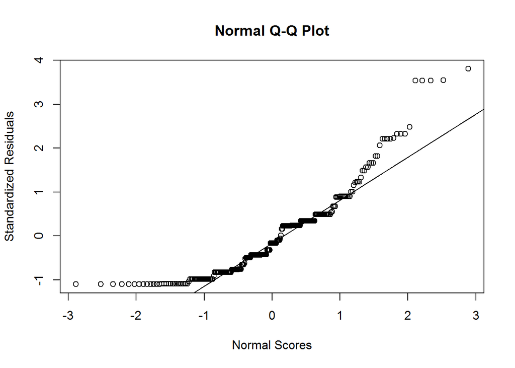

*This suggests (visually) that providing information about political/partisan aspects of the source has an impact for average contributions for Recommendations, but not for Defaults. Further investigation with Wilcoxon Test and linear OLS-regression finds no significant effects.*

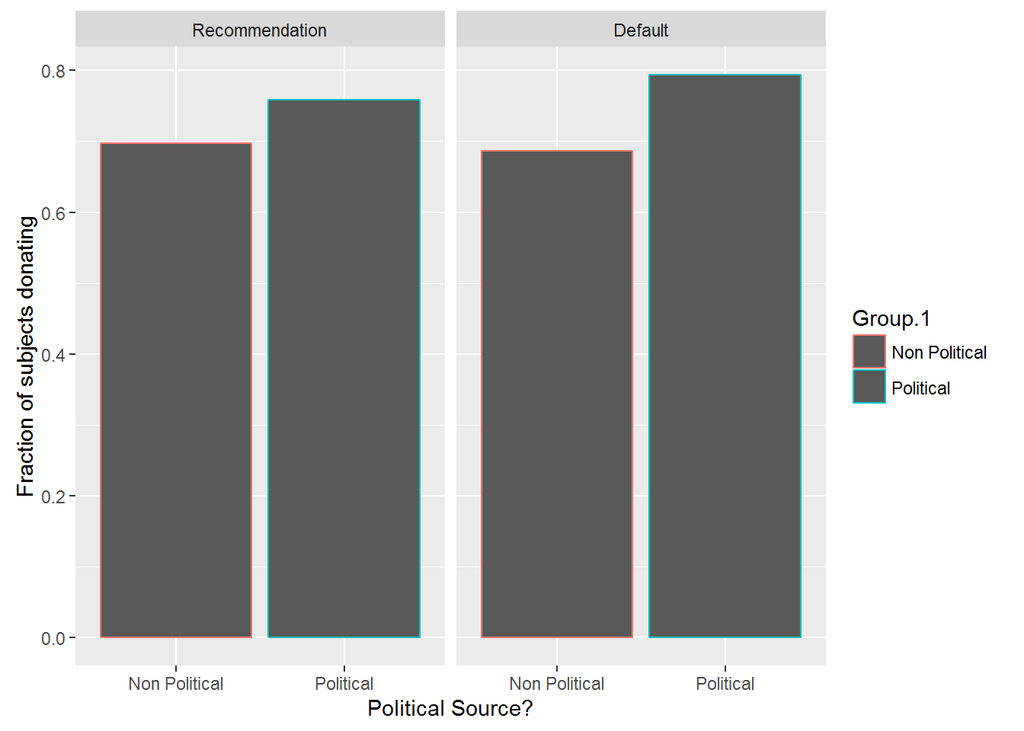

```r
m <- aggregate(df$Donatedm, list(df$NonPolvsPol, df$Intervention), sum)
m$n <- aggregate(df$Donatedm, list(df$NonPolvsPol, df$Intervention), length)[3]
ggplot(data = m, aes(x = Group.1, y = x/n, colour = Group.1)) +
  facet_grid(~Group.2) +
  geom_bar(stat = "identity") +
  xlab("Political Source?") +
  ylab("Fraction of subjects donating")
```

*There does not seem to be anything of interest here.*

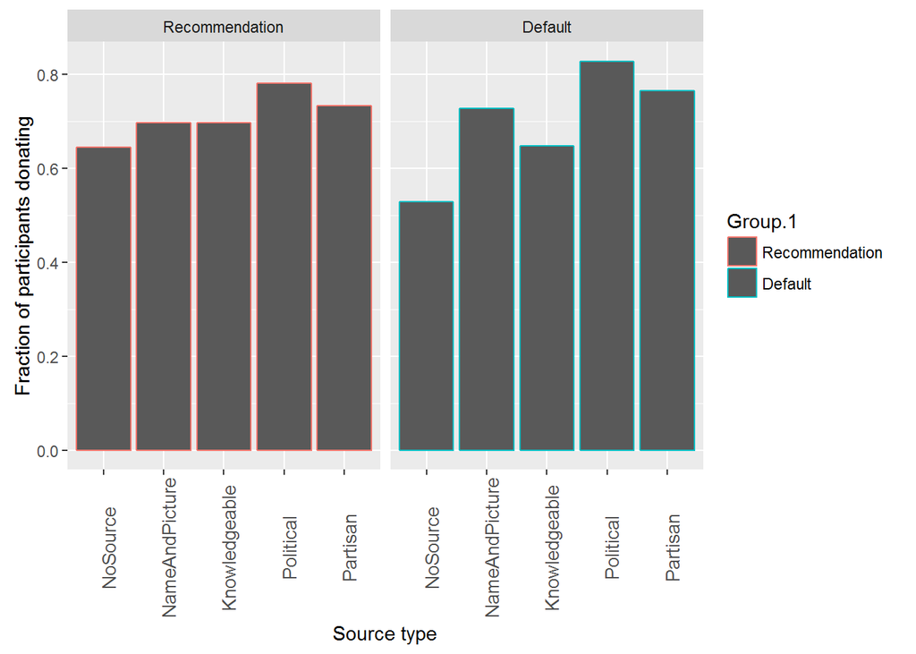

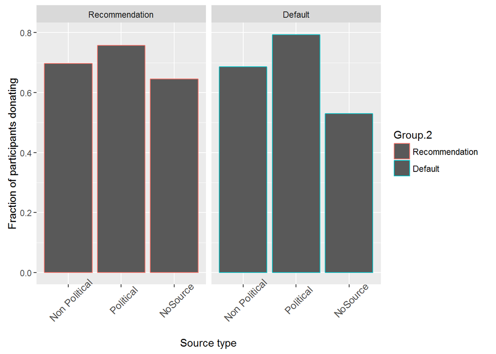

```
##
## Call:
## glm(formula = Donated ~ NonPolvsPolA * Intervention, family = "binomial",
##     data = df)
##
## Deviance Residuals:
##     Min       1Q   Median       3Q      Max
## -1.7766  -1.2278   0.7443   0.8672   1.1278
##
## Coefficients:
##                                           Estimate Std. Error z value
## (Intercept)                                0.83291    0.26784   3.110
## NonPolvsPolAPolitical                      0.30919    0.39960   0.774
## NonPolvsPolANoSource                      -0.23507    0.46114  -0.510
## InterventionDefault                       -0.04879    0.37563  -0.130
## NonPolvsPolAPolitical:InterventionDefault  0.25377    0.57093   0.444
## NonPolvsPolANoSource:InterventionDefault  -0.43126    0.63250  -0.682
##                                           Pr(>|z|)
## (Intercept)                                0.00187 **
## NonPolvsPolAPolitical                      0.43908
## NonPolvsPolANoSource                       0.61022
## InterventionDefault                        0.89665
## NonPolvsPolAPolitical:InterventionDefault  0.65670
## NonPolvsPolANoSource:InterventionDefault   0.49534
## ---
## Signif. codes:  0 '***' 0.001 '**' 0.01 '*' 0.05 '.' 0.1 ' ' 1
##
## (Dispersion parameter for binomial family taken to be 1)
##
##     Null deviance: 393.08  on 322  degrees of freedom
## Residual deviance: 384.39  on 317  degrees of freedom
##   (31 observations deleted due to missingness)
## AIC: 396.39
##
## Number of Fisher Scoring iterations: 4
```

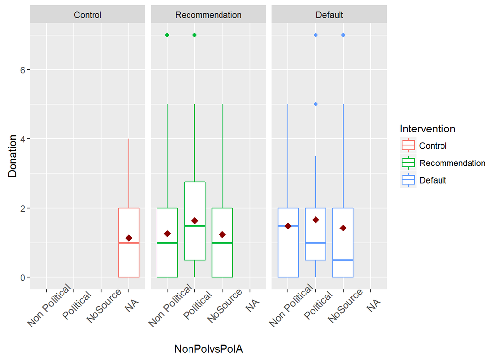

```
##
##  Kruskal-Wallis rank sum test
##
## data:  df$Donation[df$Intervention == "Recommendation"] by df$NonPolvsPolA[df$Intervention == "Recommendation"]
## Kruskal-Wallis chi-squared = 3.3912, df = 2, p-value = 0.1835
```

```
##
##  Kruskal-Wallis rank sum test
##
## data:  df$Donation[df$Intervention == "Default"] by df$NonPolvsPolA[df$Intervention == "Default"]
## Kruskal-Wallis chi-squared = 2.7509, df = 2, p-value = 0.2527
```

*The logistic regression does not produce any significant predictors. Neither do the Kruskal Wallis tests for the respective interventions.*

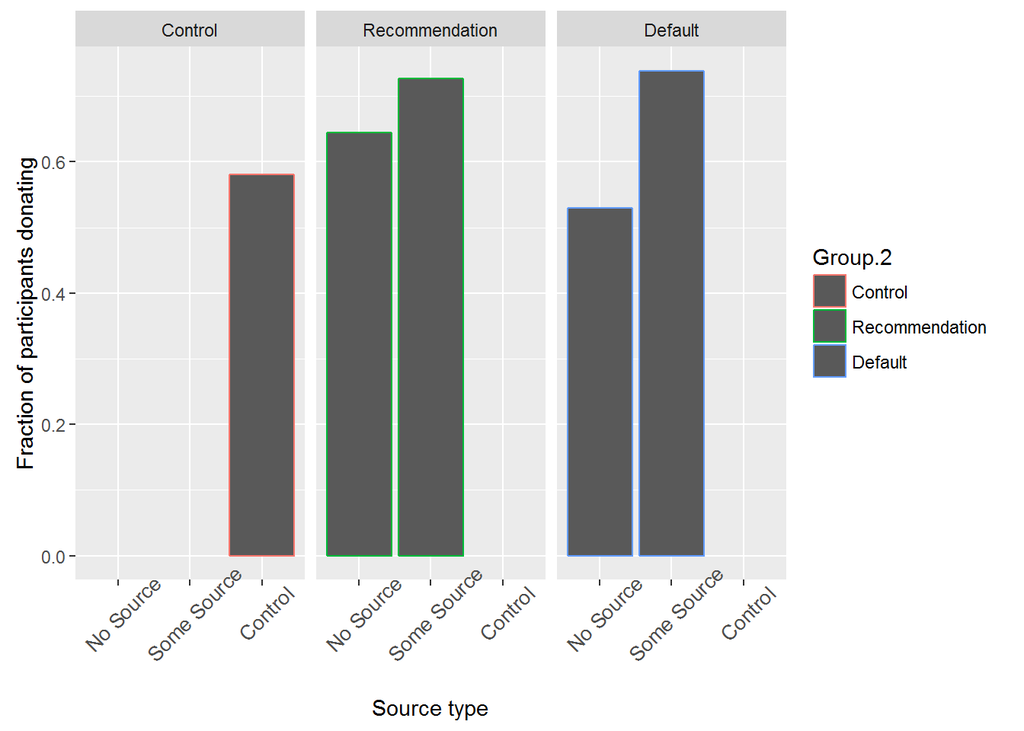

```
##
## Call:
## glm(formula = Donated ~ NosvsSome * RecvsDefD, family = "binomial",
##     data = df)
##
## Deviance Residuals:
##     Min       1Q   Median       3Q      Max
## -1.6378  -1.2278   0.7787   0.7993   1.1278
##
## Coefficients:
##                                   Estimate Std. Error z value Pr(>|z|)
## (Intercept)                         0.5978     0.3754   1.593    0.111
## NosvsSomeSome Source                0.3794     0.4245   0.894    0.371
## RecvsDefDDef                       -0.4801     0.5089  -0.943    0.346
## NosvsSomeSome Source:RecvsDefDDef   0.5408     0.5815   0.930    0.352
##
## (Dispersion parameter for binomial family taken to be 1)
##
##     Null deviance: 393.08  on 322  degrees of freedom
## Residual deviance: 386.93  on 319  degrees of freedom
##   (31 observations deleted due to missingness)
## AIC: 394.93
##
## Number of Fisher Scoring iterations: 4
```

*Suggests that the provision of any kind of source information increases the likelyhood to donate (Extensive margin), especially for defaults. However, the logistic estimation model suggests that there is no interaction between the provision of some source information and the type of intervention. When including the type of intervention, the sourcetype is not significant anymore.*

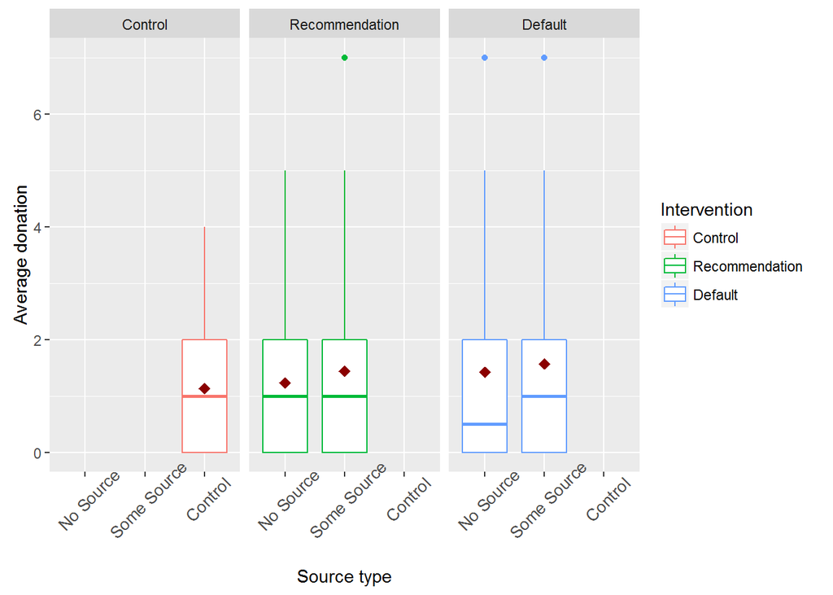

# Gender differences

## Average donation gender differences (by treatment)

```
## group: Keine Angabe
##   vars n mean   sd median trimmed  mad min max range skew kurtosis   se
## 1    1 4    3 3.56    2.5       3 3.71   0   7     7  0.1    -2.32 1.78
## --------------------------------------------------------
## group: Männlich
##   vars   n mean   sd median trimmed  mad min max range skew kurtosis   se
## 1    1 141  1.1 1.39    0.7    0.85 1.04   0   7     7 1.81        4 0.12
## --------------------------------------------------------
## group: Weiblich
##   vars   n mean   sd median trimmed  mad min max range skew kurtosis   se
## 1    1 209 1.64 1.55    1.5    1.43 1.48   0   7     7 1.13     1.35 0.11
```

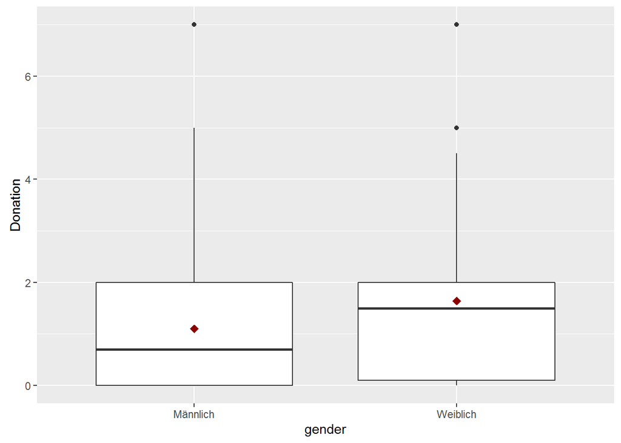

```
##
##  Welch Two Sample t-test
##
## data:  dfsub$Donation by dfsub$gender
## t = -3.4369, df = 321.65, p-value = 0.0006658
## alternative hypothesis: true difference in means is not equal to 0
## 95 percent confidence interval:
##  -0.8569099 -0.2330083
## sample estimates:
## mean in group Männlich mean in group Weiblich
##               1.098582               1.643541
```

```
##
##  Wilcoxon rank sum test with continuity correction
##
## data:  dfsub$Donation by dfsub$gender
## W = 11246, p-value = 0.0001193
## alternative hypothesis: true location shift is not equal to 0
```

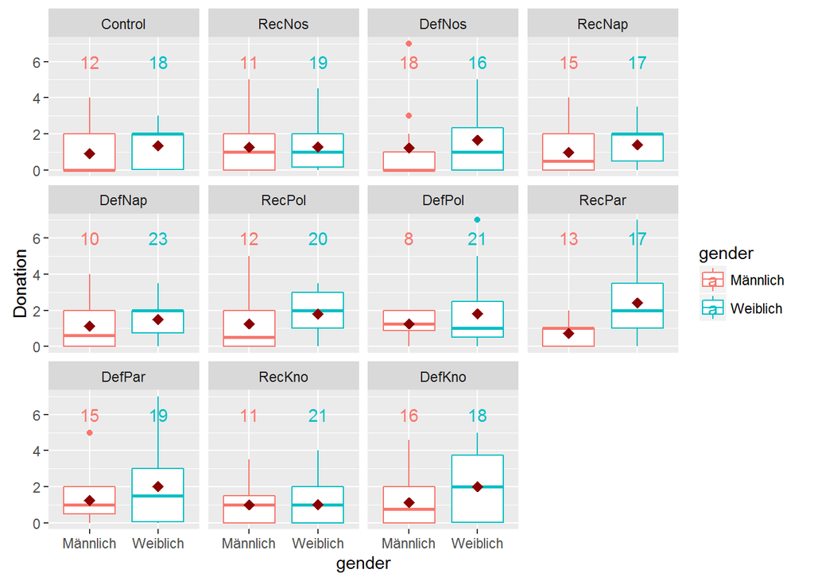

```
##
##  Kruskal-Wallis rank sum test
##
## data:  df$Donation[df$gender == "Weiblich"] by df$treatment[df$gender == "Weiblich"]
## Kruskal-Wallis chi-squared = 10.783, df = 10, p-value = 0.3746
```

```
##
##  Kruskal-Wallis rank sum test
##
## data:  df$Donation[df$gender == "Männlich"] by df$treatment[df$gender == "Männlich"]
## Kruskal-Wallis chi-squared = 3.978, df = 10, p-value = 0.9483
```

*Could be interesting. For example, when looking at Control, RecNos, RecNap, RecPol, RecPar, (And RecKno), the treatment-effect seems to be present for women, but not (or even negatively) for men. This seems to be also true for Defaults, but slightly different. However, according to two Kruskal Wallis Tests there is no treatment effect for men, and none for women.*

### Extensive margin (by treatment)

```
##
## Call:
## glm(formula = gender ~ treatment, family = "binomial", data = dfsub)
##
## Deviance Residuals:
##     Min       1Q   Median       3Q      Max
## -1.6049  -1.2793   0.8497   1.0108   1.2278
##
## Coefficients:
##                 Estimate Std. Error z value Pr(>|z|)
## (Intercept)       0.4055     0.3727   1.088    0.277
## treatmentRecNos   0.1411     0.5314   0.265    0.791
## treatmentDefNos  -0.5232     0.5069  -1.032    0.302
## treatmentRecNap  -0.2803     0.5142  -0.545    0.586
## treatmentDefNap   0.4274     0.5314   0.804    0.421
## treatmentRecPol   0.1054     0.5217   0.202    0.840
## treatmentDefPol   0.5596     0.5581   1.003    0.316
## treatmentRecPar  -0.1372     0.5241  -0.262    0.793
## treatmentDefPar  -0.1691     0.5081  -0.333    0.739
## treatmentRecKno   0.2412     0.5267   0.458    0.647
## treatmentDefKno  -0.2877     0.5069  -0.568    0.570
##
## (Dispersion parameter for binomial family taken to be 1)
##
##     Null deviance: 471.91  on 349  degrees of freedom
## Residual deviance: 463.97  on 339  degrees of freedom
## AIC: 485.97
##
## Number of Fisher Scoring iterations: 4
```

```
##
##  Pearson's Chi-squared test
##
## data:  table(factor(dfsub$gender), dfsub$treatment)
## X-squared = 7.8565, df = 10, p-value = 0.6429
```

*Gender is not significantly differently represented along tratments*

```
##
##  Pearson's Chi-squared test with Yates' continuity correction
##
## data:  table(dfsub$Donated, factor(dfsub$gender))
## X-squared = 10.039, df = 1, p-value = 0.001533
```

```
##
## Call:
## glm(formula = Donated ~ treatment * gender, family = "binomial",
##     data = dfsub)
##
## Deviance Residuals:
##     Min       1Q   Median       3Q      Max
## -2.1460  -1.2557   0.6841   0.8203   1.3232
##
## Coefficients:
##                                Estimate Std. Error z value Pr(>|z|)
## (Intercept)                     -0.3365     0.5855  -0.575   0.5655
## treatmentRecNos                  0.5188     0.8423   0.616   0.5380
## treatmentDefNos                  0.1133     0.7536   0.150   0.8805
## treatmentRecNap                  0.7419     0.7878   0.942   0.3463
## treatmentDefNap                  0.7419     0.8715   0.851   0.3946
## treatmentRecPol                  0.6729     0.8281   0.813   0.4164
## treatmentDefPol                  2.2824     1.2189   1.873   0.0611 .
## treatmentRecPar                  0.8065     0.8172   0.987   0.3237
## treatmentDefPar                  1.7228     0.8715   1.977   0.0481 *
## treatmentRecKno                  0.8961     0.8577   1.045   0.2962
## treatmentDefKno                  0.5878     0.7725   0.761   0.4467
## genderWeiblich                   1.2920     0.7873   1.641   0.1008
## treatmentRecNos:genderWeiblich  -0.4447     1.1216  -0.396   0.6917
## treatmentDefNos:genderWeiblich  -0.5580     1.0543  -0.529   0.5966
## treatmentRecNap:genderWeiblich  -0.5188     1.1066  -0.469   0.6392
## treatmentDefNap:genderWeiblich  -0.4165     1.1367  -0.366   0.7140
## treatmentRecPol:genderWeiblich   0.5688     1.2321   0.462   0.6444
## treatmentDefPol:genderWeiblich  -1.7910     1.4393  -1.244   0.2134
## treatmentRecPar:genderWeiblich  -0.2215     1.1617  -0.191   0.8488
## treatmentDefPar:genderWeiblich  -1.6487     1.1436  -1.442   0.1494
## treatmentRecKno:genderWeiblich  -0.9353     1.1162  -0.838   0.4021
## treatmentDefKno:genderWeiblich  -0.5878     1.0727  -0.548   0.5837
## ---
## Signif. codes:  0 '***' 0.001 '**' 0.01 '*' 0.05 '.' 0.1 ' ' 1
##
## (Dispersion parameter for binomial family taken to be 1)
##
##     Null deviance: 430.94  on 349  degrees of freedom
## Residual deviance: 405.43  on 328  degrees of freedom
## AIC: 449.43
##
## Number of Fisher Scoring iterations: 4
```

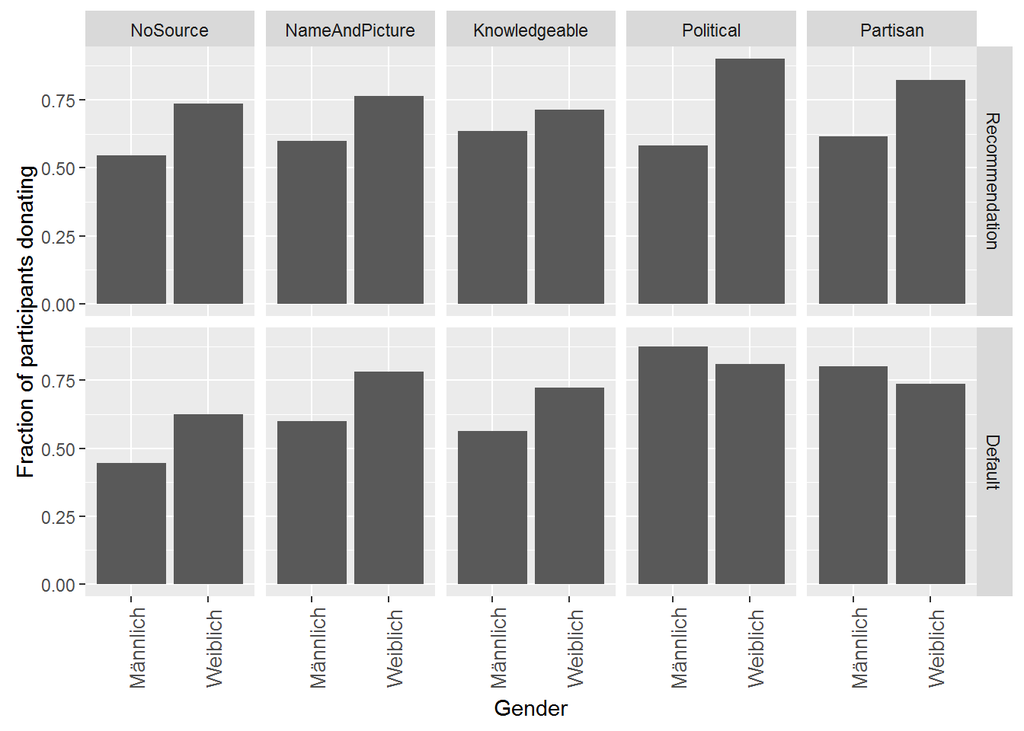

*Judging based on the logistic regression, controlling for gender, contributing is significantly more likely for subjects seeing a default by a partisan-source compared to the control group, i.e. seeing no intervention and source.*

## Gender differences (by Intervention type)

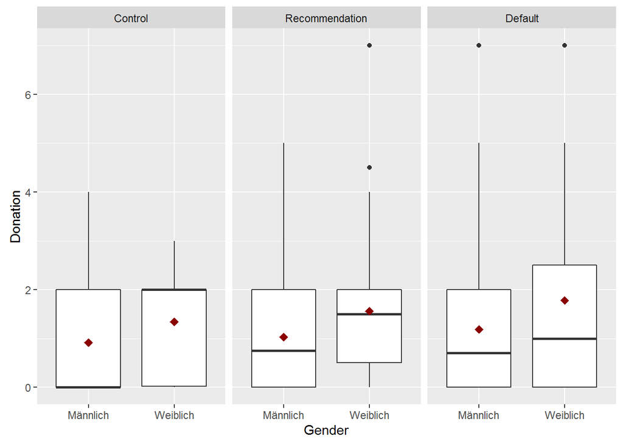

## Gender differences (by Source type)

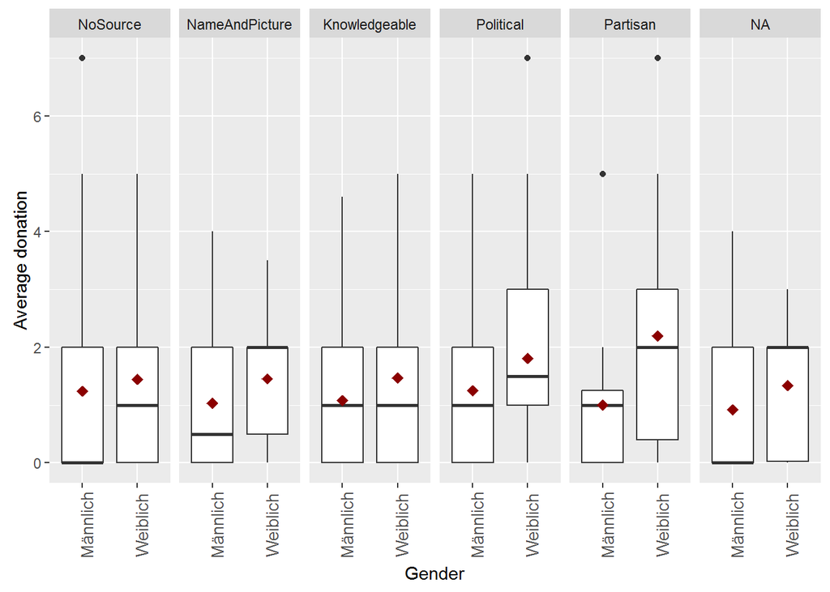

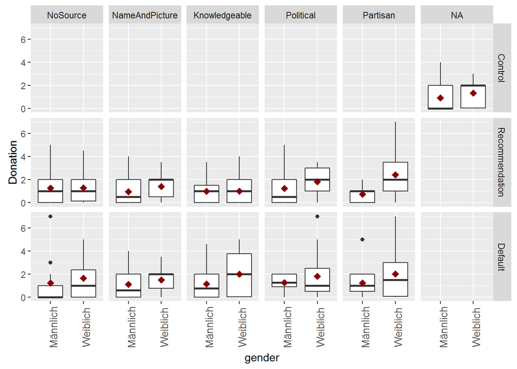

```
##
##  Kruskal-Wallis rank sum test
##
## data:  dfsub$Donation[dfsub$gender == "Weiblich" & dfsub$Intervention == "Recommendation"] by dfsub$Sourcetype[dfsub$gender == "Weiblich" & dfsub$Intervention == "Recommendation"]
## Kruskal-Wallis chi-squared = 10.733, df = 4, p-value = 0.02973
```

```
##
##  Kruskal-Wallis rank sum test
##
## data:  dfsub$Donation[dfsub$gender == "Weiblich" & dfsub$Intervention == "Default"] by dfsub$Sourcetype[dfsub$gender == "Weiblich" & dfsub$Intervention == "Default"]
## Kruskal-Wallis chi-squared = 0.61934, df = 4, p-value = 0.9609
```

```
##
##  Kruskal-Wallis rank sum test
##
## data:  dfsub$Donation[dfsub$gender == "Männlich" & dfsub$Intervention == "Recommendation"] by dfsub$Sourcetype[dfsub$gender == "Männlich" & dfsub$Intervention == "Recommendation"]
## Kruskal-Wallis chi-squared = 0.40054, df = 4, p-value = 0.9824
```

```
##
##  Kruskal-Wallis rank sum test
##
## data:  dfsub$Donation[dfsub$gender == "Männlich" & dfsub$Intervention == "Default"] by dfsub$Sourcetype[dfsub$gender == "Männlich" & dfsub$Intervention == "Default"]
## Kruskal-Wallis chi-squared = 2.8933, df = 4, p-value = 0.5758
```

```
##
## Call:
## lm(formula = Donation ~ gender * RecvsDefD * Sourcetype, data = dfsub)
##
## Residuals:
##     Min      1Q  Median      3Q     Max
## -2.4118 -1.1200 -0.2789  0.7667  5.7778
##
## Coefficients:
##                                                       Estimate Std. Error
## (Intercept)                                           1.272727   0.459882
## genderWeiblich                                        0.006220   0.577870
## RecvsDefDDef                                         -0.050505   0.583726
## SourcetypeNameAndPicture                             -0.299394   0.605463
## SourcetypeKnowledgeable                              -0.272727   0.650371
## SourcetypePolitical                                  -0.022727   0.636678
## SourcetypePartisan                                   -0.541958   0.624856
## genderWeiblich:RecvsDefDDef                           0.421558   0.780114
## genderWeiblich:SourcetypeNameAndPicture               0.432211   0.791122
## genderWeiblich:SourcetypeKnowledgeable               -0.001458   0.810065
## genderWeiblich:SourcetypePolitical                    0.553780   0.802571
## genderWeiblich:SourcetypePartisan                     1.674775   0.806061
## RecvsDefDDef:SourcetypeNameAndPicture                 0.197172   0.853504
## RecvsDefDDef:SourcetypeKnowledgeable                  0.181755   0.835241
## RecvsDefDDef:SourcetypePolitical                      0.050505   0.908517
## RecvsDefDDef:SourcetypePartisan                       0.553069   0.821452
## genderWeiblich:RecvsDefDDef:SourcetypeNameAndPicture -0.493033   1.110994
## genderWeiblich:RecvsDefDDef:SourcetypeKnowledgeable   0.447986   1.097951
## genderWeiblich:RecvsDefDDef:SourcetypePolitical      -0.422034   1.149064
## genderWeiblich:RecvsDefDDef:SourcetypePartisan       -1.330623   1.096319
##                                                      t value Pr(>|t|)
## (Intercept)                                            2.768   0.0060 **
## genderWeiblich                                         0.011   0.9914
## RecvsDefDDef                                          -0.087   0.9311
## SourcetypeNameAndPicture                              -0.494   0.6213
## SourcetypeKnowledgeable                               -0.419   0.6753
## SourcetypePolitical                                   -0.036   0.9715
## SourcetypePartisan                                    -0.867   0.3865
## genderWeiblich:RecvsDefDDef                            0.540   0.5893
## genderWeiblich:SourcetypeNameAndPicture                0.546   0.5852
## genderWeiblich:SourcetypeKnowledgeable                -0.002   0.9986
## genderWeiblich:SourcetypePolitical                     0.690   0.4907
## genderWeiblich:SourcetypePartisan                      2.078   0.0386 *
## RecvsDefDDef:SourcetypeNameAndPicture                  0.231   0.8175
## RecvsDefDDef:SourcetypeKnowledgeable                   0.218   0.8279
## RecvsDefDDef:SourcetypePolitical                       0.056   0.9557
## RecvsDefDDef:SourcetypePartisan                        0.673   0.5013
## genderWeiblich:RecvsDefDDef:SourcetypeNameAndPicture  -0.444   0.6575
## genderWeiblich:RecvsDefDDef:SourcetypeKnowledgeable    0.408   0.6835
## genderWeiblich:RecvsDefDDef:SourcetypePolitical       -0.367   0.7137
## genderWeiblich:RecvsDefDDef:SourcetypePartisan        -1.214   0.2258
## ---
## Signif. codes:  0 '***' 0.001 '**' 0.01 '*' 0.05 '.' 0.1 ' ' 1
##
## Residual standard error: 1.525 on 300 degrees of freedom
##   (30 observations deleted due to missingness)
## Multiple R-squared:  0.07393,    Adjusted R-squared:  0.01528
## F-statistic: 1.261 on 19 and 300 DF,  p-value: 0.2084
```

```
##
##  Kruskal-Wallis rank sum test
##
## data:  dfsub$Donation[dfsub$gender == "Weiblich" & dfsub$Intervention == "Recommendation"] by dfsub$NonPolvsPolA[dfsub$gender == "Weiblich" & dfsub$Intervention == "Recommendation"]
## Kruskal-Wallis chi-squared = 8.9371, df = 2, p-value = 0.01146
```

*Same as above, the treatment effect seems to be present for females, but only when the source of the recommendation is political or associated with the green party. For males, the treatment effect seems to be zero, or slightly negative. Kruskal Wallis Tests confirm this (threat of sequential tests, so maybe Bonferroni correction should be used).*

## Gender and Reactance interaction per treatment

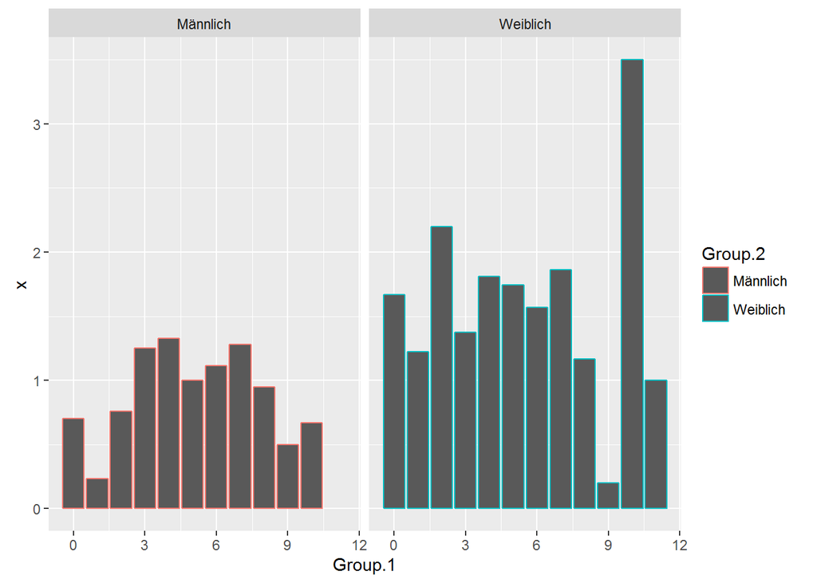

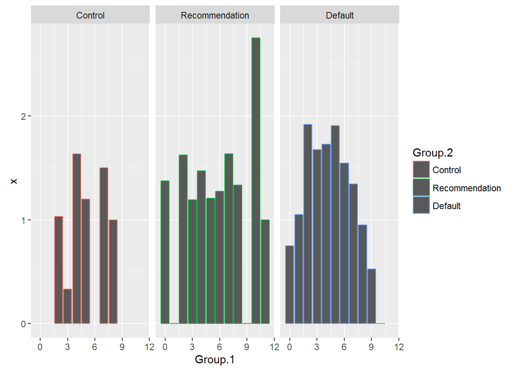

# Party preference differences

# Including only “believers” in Julia Verlinden

## First check if whether subjects believe we cooperated depends on treatment

```
##
##  Pearson's Chi-squared test
##
## data:  table(dfbelA$believe2, dfbelA$treatment)
## X-squared = 11.612, df = 7, p-value = 0.1141
```

```
##
## Call:
## glm(formula = believe2 ~ treatment, family = "binomial", data = dfbelA)
##
## Deviance Residuals:
##     Min       1Q   Median       3Q      Max
## -1.6835  -1.2068   0.7452   1.1010   1.2310
##
## Coefficients:
##                 Estimate Std. Error z value Pr(>|z|)
## (Intercept)      0.18232    0.34960   0.522   0.6020
## treatmentDefNap  0.79851    0.52440   1.523   0.1278
## treatmentRecPol -0.30748    0.49771  -0.618   0.5367
## treatmentDefPol -0.11333    0.51021  -0.222   0.8242
## treatmentRecPar -0.04879    0.50611  -0.096   0.9232
## treatmentDefPar -0.30010    0.49018  -0.612   0.5404
## treatmentRecKno  0.95711    0.53593   1.786   0.0741 .
## treatmentDefKno  0.29725    0.49675   0.598   0.5496
## ---
## Signif. codes:  0 '***' 0.001 '**' 0.01 '*' 0.05 '.' 0.1 ' ' 1
##
## (Dispersion parameter for binomial family taken to be 1)
##
##     Null deviance: 350.80  on 257  degrees of freedom
## Residual deviance: 338.81  on 250  degrees of freedom
## AIC: 354.81
##
## Number of Fisher Scoring iterations: 4
```

```
##
## Call:
## glm(formula = believe2 ~ Sourcetype * Intervention, family = "binomial",
##     data = dfbelA)
##
## Deviance Residuals:
##     Min       1Q   Median       3Q      Max
## -1.6835  -1.2068   0.7452   1.1010   1.2310
##
## Coefficients:
##                                             Estimate Std. Error z value
## (Intercept)                                  0.18232    0.34960   0.522
## SourcetypeKnowledgeable                      0.95711    0.53593   1.786
## SourcetypePolitical                         -0.30748    0.49771  -0.618
## SourcetypePartisan                          -0.04879    0.50611  -0.096
## InterventionDefault                          0.79851    0.52440   1.523
## SourcetypeKnowledgeable:InterventionDefault -1.45837    0.75136  -1.941
## SourcetypePolitical:InterventionDefault     -0.60435    0.73388  -0.823
## SourcetypePartisan:InterventionDefault      -1.04982    0.72594  -1.446
##                                             Pr(>|z|)
## (Intercept)                                   0.6020
## SourcetypeKnowledgeable                       0.0741 .
## SourcetypePolitical                           0.5367
## SourcetypePartisan                            0.9232
## InterventionDefault                           0.1278
## SourcetypeKnowledgeable:InterventionDefault   0.0523 .
## SourcetypePolitical:InterventionDefault       0.4102
## SourcetypePartisan:InterventionDefault        0.1481
## ---
## Signif. codes:  0 '***' 0.001 '**' 0.01 '*' 0.05 '.' 0.1 ' ' 1
##
## (Dispersion parameter for binomial family taken to be 1)
##
##     Null deviance: 350.80  on 257  degrees of freedom
## Residual deviance: 338.81  on 250  degrees of freedom
## AIC: 354.81
##
## Number of Fisher Scoring iterations: 4
```

*Potentially interesting that subjects are more likely to not believe we cooperated with Julia when they are confronted with source information of a knowledgeable actor, but that this positive effect is weakened (negative interaction) when provided for a default, instead of a recommendation.*

## What explains the probability that people believe we cooperated with Julia?

```
##
##  Pearson's Chi-squared test with simulated p-value (based on 2000
##  replicates)
##
## data:  table(dfbelA$believe2, dfbelA$gender)
## X-squared = 2.9328, df = NA, p-value = 0.2774
```

```
##
##  Pearson's Chi-squared test
##
## data:  table(dfbelA$believe2, dfbelA$trustPol)
## X-squared = NaN, df = 4, p-value = NA
```

```
##
##  Pearson's Chi-squared test with simulated p-value (based on 2000
##  replicates)
##
## data:  table(dfbelA$believe2, dfbelA$party)
## X-squared = 1.8762, df = NA, p-value = 0.9845
```

```
##
## Call:
## glm(formula = believe2 ~ Reactance, family = "binomial", data = dfbelA)
##
## Deviance Residuals:
##    Min      1Q  Median      3Q     Max
## -1.333  -1.318   1.036   1.043   1.057
##
## Coefficients:
##              Estimate Std. Error z value Pr(>|z|)
## (Intercept)  0.359080   0.298481   1.203    0.229
## Reactance   -0.006874   0.060777  -0.113    0.910
##
## (Dispersion parameter for binomial family taken to be 1)
##
##     Null deviance: 350.80  on 257  degrees of freedom
## Residual deviance: 350.78  on 256  degrees of freedom
## AIC: 354.78
##
## Number of Fisher Scoring iterations: 4
```

```
##
## Call:
## glm(formula = believe2 ~ demandEffectD, family = "binomial",
##     data = dfbelA)
##
## Deviance Residuals:
##     Min       1Q   Median       3Q      Max
## -1.3877  -1.3018   0.9808   1.0579   1.0579
##
## Coefficients:
##                     Estimate Std. Error z value Pr(>|z|)
## (Intercept)           0.2877     0.1418   2.028   0.0425 *
## demandEffectDDemEff   0.1942     0.3117   0.623   0.5333
## ---
## Signif. codes:  0 '***' 0.001 '**' 0.01 '*' 0.05 '.' 0.1 ' ' 1
##
## (Dispersion parameter for binomial family taken to be 1)
##
##     Null deviance: 350.8  on 257  degrees of freedom
## Residual deviance: 350.4  on 256  degrees of freedom
## AIC: 354.4
##
## Number of Fisher Scoring iterations: 4
```

*Whether or not respondents believe us that we cooperated with Julia does not depend on gender (Chi²Test with simulated p-values), trust in Pol (missing observations), party affiliation (Chi²Test with simulated p-values), Reactance score (treated as metric in a logistic regression), experiencing a demand effect (dummy in a logistic regression). Note that I did not include treatment-IVs, meaning I assume that the respective IV is independent of treatment (i.e. not significantly different among treatments).*

```
##
##  Pearson's Chi-squared test with simulated p-value (based on 2000
##  replicates)
##
## data:  df$demandEffectD and df$treatment
## X-squared = 13.478, df = NA, p-value = 0.1909
```

```
##
## Call:
## glm(formula = demandEffectD ~ treatment, family = "binomial",
##     data = df)
##
## Deviance Residuals:
##     Min       1Q   Median       3Q      Max
## -0.9331  -0.7842  -0.5931  -0.4366   2.1899
##
## Coefficients:
##                 Estimate Std. Error z value Pr(>|z|)
## (Intercept)     -1.64866    0.48833  -3.376 0.000735 ***
## treatmentRecNos  0.75484    0.62851   1.201 0.229752
## treatmentDefNos  0.29873    0.64680   0.462 0.644183
## treatmentRecNap  0.33647    0.64790   0.519 0.603535
## treatmentDefNap -0.65393    0.77780  -0.841 0.400497
## treatmentRecPol -0.03774    0.68956  -0.055 0.956353
## treatmentDefPol  0.30492    0.66978   0.455 0.648923
## treatmentRecPar -0.54857    0.78024  -0.703 0.482009
## treatmentDefPar  0.62701    0.62416   1.005 0.315106
## treatmentRecKno  0.81575    0.61801   1.320 0.186850
## treatmentDefKno  1.04252    0.60601   1.720 0.085377 .
## ---
## Signif. codes:  0 '***' 0.001 '**' 0.01 '*' 0.05 '.' 0.1 ' ' 1
##
## (Dispersion parameter for binomial family taken to be 1)
##
##     Null deviance: 368.23  on 353  degrees of freedom
## Residual deviance: 354.27  on 343  degrees of freedom
## AIC: 376.27
##
## Number of Fisher Scoring iterations: 4
```

*According to the ChiÂ²Test, whether or not people experienced an experimenter demand effect does not depend on treatment. According to the logistic regression, whether or not people experienced an experimenter demand effect depends on treatment, but only slgihtly significant for DefKno.*

## Check average donations by treatment only for those that believed we cooperated with Julia Verlinden

```
## group: Control
##   vars  n mean   sd median trimmed  mad min max range skew kurtosis   se
## 1    1 31 1.13 1.15      1    1.02 1.48   0   4     4 0.42    -0.94 0.21
## --------------------------------------------------------
## group: RecNos
##   vars  n mean   sd median trimmed  mad min max range skew kurtosis   se
## 1    1 31 1.24 1.39      1    0.99 1.48   0   5     5 1.14     0.52 0.25
## --------------------------------------------------------
## group: DefNos
##   vars  n mean   sd median trimmed  mad min max range skew kurtosis   se
## 1    1 34 1.42 2.08    0.5    1.05 0.74   0   7     7 1.46     0.93 0.36
## --------------------------------------------------------
## group: RecNap
##   vars  n mean   sd median trimmed  mad min max range skew kurtosis   se
## 1    1 18 0.98 0.96   0.75    0.91 1.11   0   3     3  0.5    -1.17 0.23
## --------------------------------------------------------
## group: DefNap
##   vars  n mean  sd median trimmed  mad min max range skew kurtosis   se
## 1    1 24  1.5 1.2      2    1.43 1.48   0   4     4 0.18    -1.09 0.25
## --------------------------------------------------------
## group: RecPol
##   vars  n mean  sd median trimmed  mad min max range skew kurtosis   se
## 1    1 15 1.65 1.5    1.5    1.52 2.22   0   5     5  0.6    -0.66 0.39
## --------------------------------------------------------
## group: DefPol
##   vars  n mean   sd median trimmed  mad min max range skew kurtosis   se
## 1    1 15 1.63 1.38      1     1.5 1.48   0   5     5 0.92    -0.05 0.36
## --------------------------------------------------------
## group: RecPar
##   vars  n mean   sd median trimmed  mad min max range skew kurtosis   se
## 1    1 16 1.81 1.12      2    1.79 1.48   0   4     4 0.34       -1 0.28
## --------------------------------------------------------
## group: DefPar
##   vars  n mean   sd median trimmed  mad min max range skew kurtosis   se
## 1    1 16 1.16 1.32      1    0.97 1.04   0   5     5 1.55     1.87 0.33
## --------------------------------------------------------
## group: RecKno
##   vars  n mean   sd median trimmed  mad min max range skew kurtosis   se
## 1    1 25 1.06 1.14      1    0.91 1.48   0   4     4 0.92     0.02 0.23
## --------------------------------------------------------
## group: DefKno
##   vars  n mean  sd median trimmed  mad min max range skew kurtosis   se
## 1    1 21 1.12 1.5    0.1    0.86 0.15   0   5     5 1.09     0.11 0.33
```

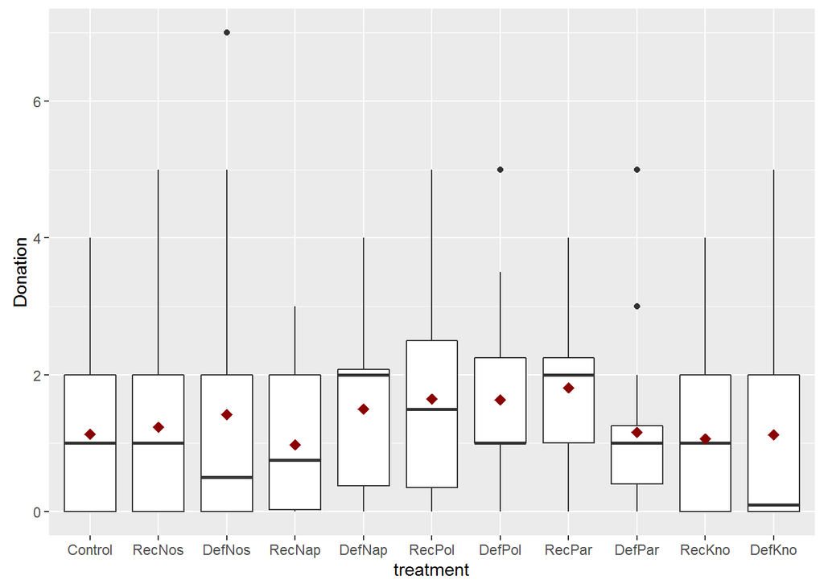

```
##
##  Kruskal-Wallis rank sum test
##
## data:  dfbel$Donation by dfbel$treatment
## Kruskal-Wallis chi-squared = 11.22, df = 10, p-value = 0.3406
```

*Kruskal Wallis test is not significant. This means that there are also no significant differences in Donations for those that believed we cooperated with Julia Verlinden.*

## Check extensive margin by treatment only for those that believed we cooperated with Julia Verlinden

```
##
##               Control RecNos DefNos RecNap DefNap RecPol DefPol RecPar
##   Not donated      13     11     16      5      6      4      2      1
##   Donated          18     20     18     13     18     11     13     15
##
##               DefPar RecKno DefKno
##   Not donated      3      8     10
##   Donated         13     17     11
```

```
##
## Call:
## glm(formula = Donated ~ treatment, family = "binomial", data = dfbel)
##
## Deviance Residuals:
##     Min       1Q   Median       3Q      Max
## -2.3548  -1.2278   0.7585   0.9362   1.1372
##
## Coefficients:
##                 Estimate Std. Error z value Pr(>|z|)
## (Intercept)       0.3254     0.3640   0.894   0.3713
## treatmentRecNos   0.2724     0.5229   0.521   0.6024
## treatmentDefNos  -0.2076     0.5005  -0.415   0.6783
## treatmentRecNap   0.6301     0.6398   0.985   0.3247
## treatmentDefNap   0.7732     0.5956   1.298   0.1942
## treatmentRecPol   0.6862     0.6880   0.997   0.3186
## treatmentDefPol   1.5464     0.8423   1.836   0.0664 .
## treatmentRecPar   2.3826     1.0950   2.176   0.0296 *
## treatmentDefPar   1.1409     0.7367   1.549   0.1215
## treatmentRecKno   0.4283     0.5624   0.762   0.4463
## treatmentDefKno  -0.2301     0.5687  -0.405   0.6857
## ---
## Signif. codes:  0 '***' 0.001 '**' 0.01 '*' 0.05 '.' 0.1 ' ' 1
##
## (Dispersion parameter for binomial family taken to be 1)
##
##     Null deviance: 308.84  on 245  degrees of freedom
## Residual deviance: 290.28  on 235  degrees of freedom
## AIC: 312.28
##
## Number of Fisher Scoring iterations: 5
```

```
##
##  Pearson's Chi-squared test with simulated p-value (based on 2000
##  replicates)
##
## data:  table(dfbel$Donated, dfbel$treatment)
## X-squared = 16.896, df = NA, p-value = 0.07096
```

*Among those that believed we cooperated with Julia Verlinden, those who were confronted with a DefPol and RecPar were more likely than those in the control group to donate. Mind, however, that there are not much observations in the respective groups (not much variation).*

# Treatment interactions with…

## … personal Interest and Knowledge w.r.t climate protection

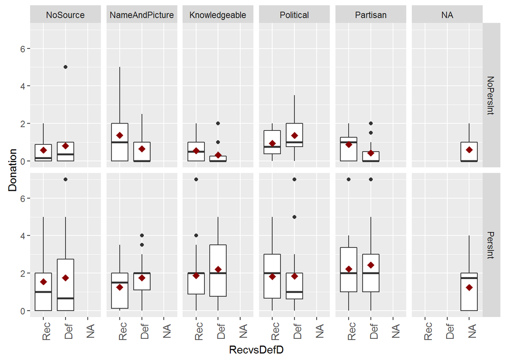

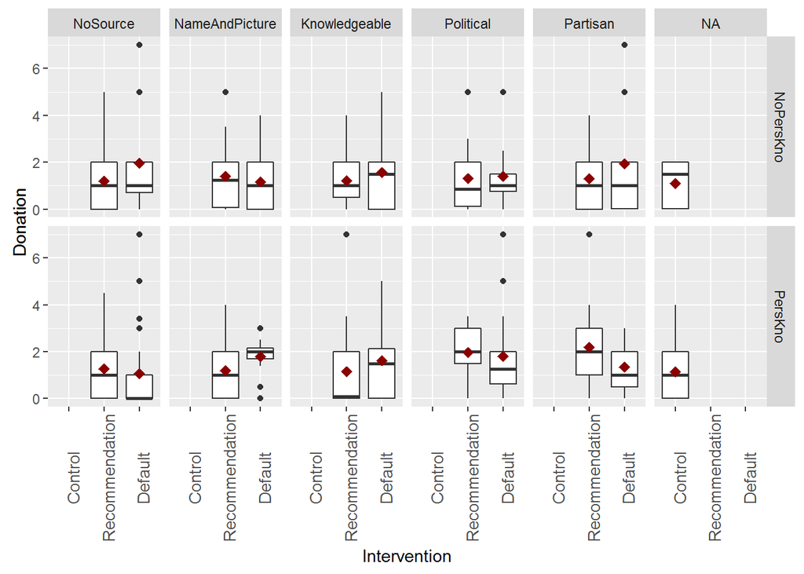

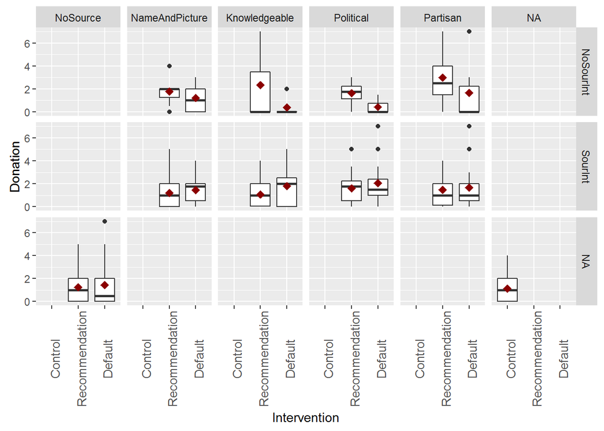

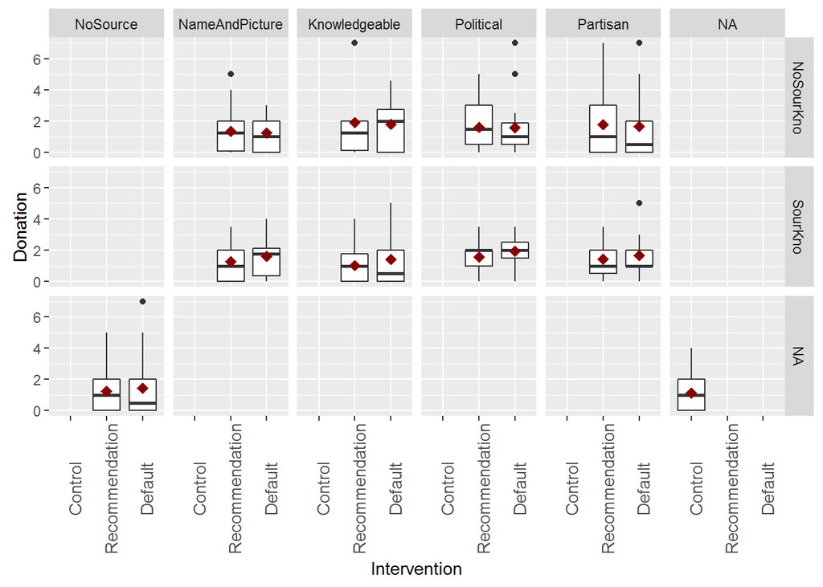

## … alignment of interest/ knowledge between subject and the subject’s perception of the source

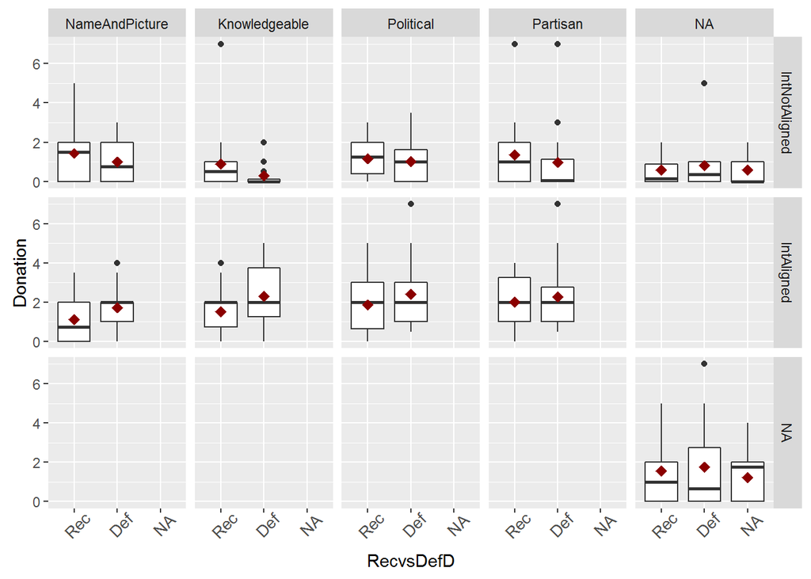

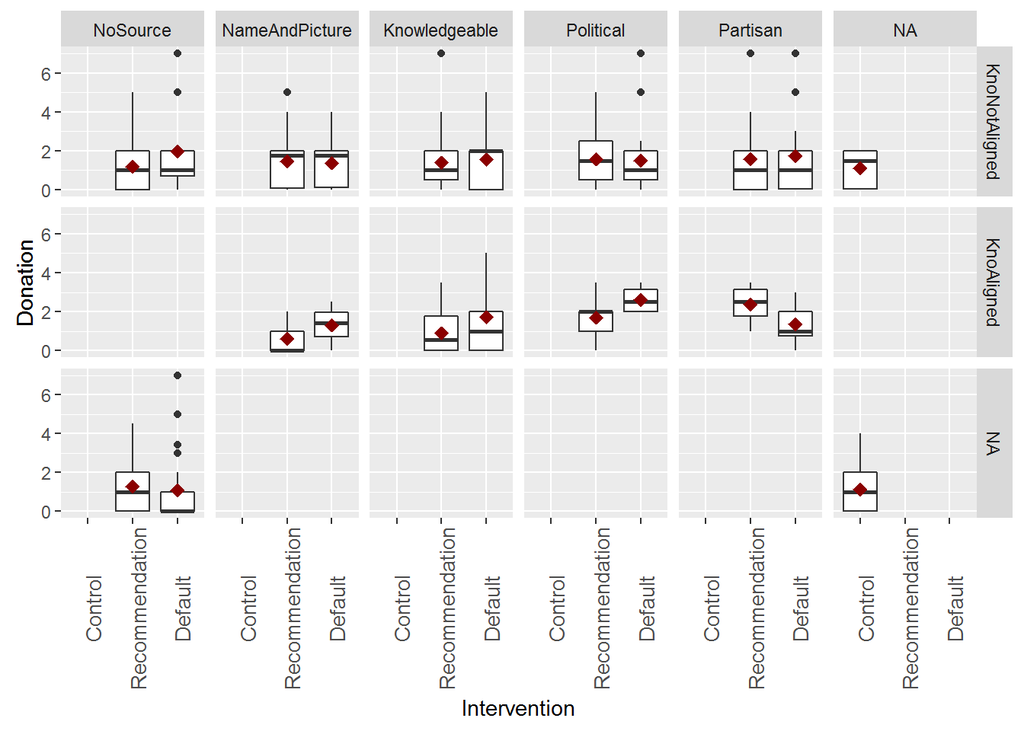

```
##
## Call:
## lm(formula = Donation ~ RecvsDefD + SourcetypeD * intAlign +
##     knowAlign, data = df)
##
## Residuals:
##     Min      1Q  Median      3Q     Max
## -2.1577 -1.1387 -0.1771  0.7813  6.3092
##
## Coefficients:
##                                             Estimate Std. Error t value
## (Intercept)                                  1.21867    0.25269   4.823
## RecvsDefDDef                                 0.07733    0.18417   0.420
## SourcetypeDKnowledgeable                    -0.52786    0.36386  -1.451
## SourcetypeDPolitical                        -0.15728    0.36613  -0.430
## SourcetypeDPartisan                         -0.06464    0.35606  -0.182
## intAlignIntAligned                           0.27035    0.36637   0.738
## knowAlignKnoAligned                         -0.22802    0.23801  -0.958
## SourcetypeDKnowledgeable:intAlignIntAligned  1.07103    0.50979   2.101
## SourcetypeDPolitical:intAlignIntAligned      0.76799    0.52441   1.464
## SourcetypeDPartisan:intAlignIntAligned       0.73333    0.51487   1.424
##                                             Pr(>|t|)
## (Intercept)                                 2.47e-06 ***
## RecvsDefDDef                                  0.6749
## SourcetypeDKnowledgeable                      0.1481
## SourcetypeDPolitical                          0.6679
## SourcetypeDPartisan                           0.8561
## intAlignIntAligned                            0.4613
## knowAlignKnoAligned                           0.3390
## SourcetypeDKnowledgeable:intAlignIntAligned   0.0367 *
## SourcetypeDPolitical:intAlignIntAligned       0.1443
## SourcetypeDPartisan:intAlignIntAligned        0.1556
## ---
## Signif. codes:  0 '***' 0.001 '**' 0.01 '*' 0.05 '.' 0.1 ' ' 1
##
## Residual standard error: 1.457 on 248 degrees of freedom
##   (96 observations deleted due to missingness)
## Multiple R-squared:  0.1154, Adjusted R-squared:  0.08327
## F-statistic: 3.594 on 9 and 248 DF,  p-value: 0.0003173
```

## … warm Glow feeling/ feeling of guilt when (not) protecting the climate

```
## group: NoWG
##   vars   n mean   sd median trimmed  mad min max range skew kurtosis   se
## 1    1 126 0.93 1.38   0.05    0.67 0.07   0   7     7 2.09     5.23 0.12
## --------------------------------------------------------
## group: WG
##   vars   n mean   sd median trimmed  mad min max range skew kurtosis  se
## 1    1 228 1.72 1.56   1.75    1.51 1.56   0   7     7 1.16     1.42 0.1
```

```
##
##               NoWG  WG
##   Not donated   63  46
##   Donated       63 182
```

```
##
##  Pearson's Chi-squared test with Yates' continuity correction
##
## data:  table(df$Donated, df$warmGlowD)
## X-squared = 32.489, df = 1, p-value = 1.199e-08
```

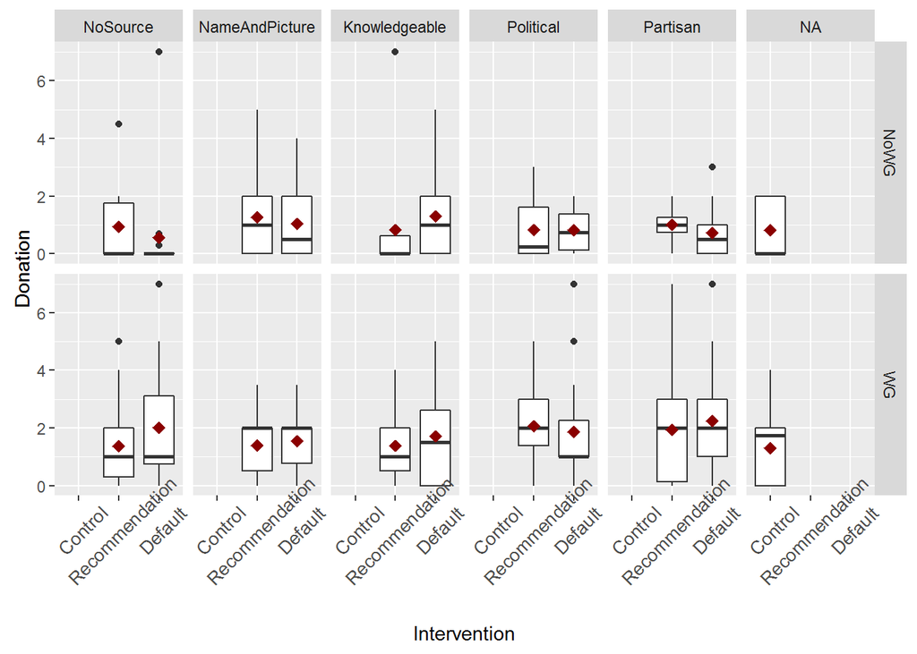

```
##
## Call:
## lm(formula = Donation ~ RecvsDefD + Sourcetype + warmGlowD, data = df)
##
## Residuals:
##     Min      1Q  Median      3Q     Max
## -1.9814 -0.9603 -0.5160  0.5631  6.1941
##
## Coefficients:
##                          Estimate Std. Error t value Pr(>|t|)
## (Intercept)               0.77839    0.23650   3.291  0.00111 **
## RecvsDefDDef              0.09674    0.17119   0.565  0.57240
## SourcetypeNameAndPicture  0.08515    0.26859   0.317  0.75142
## SourcetypeKnowledgeable   0.02749    0.26726   0.103  0.91815
## SourcetypePolitical       0.23765    0.27401   0.867  0.38643
## SourcetypePartisan        0.30590    0.27031   1.132  0.25863
## warmGlowDWG               0.80037    0.17980   4.451 1.18e-05 ***
## ---
## Signif. codes:  0 '***' 0.001 '**' 0.01 '*' 0.05 '.' 0.1 ' ' 1
##
## Residual standard error: 1.534 on 316 degrees of freedom
##   (31 observations deleted due to missingness)
## Multiple R-squared:  0.0688, Adjusted R-squared:  0.05112
## F-statistic: 3.891 on 6 and 316 DF,  p-value: 0.0009162
```

```
##
## Call:
## glm(formula = Donated ~ RecvsDefD + Sourcetype + warmGlowD, family = "binomial",
##     data = df)
##
## Deviance Residuals:
##     Min       1Q   Median       3Q      Max
## -2.0852  -0.9775   0.5610   0.7915   1.4583
##
## Coefficients:
##                          Estimate Std. Error z value Pr(>|z|)
## (Intercept)               -0.4903     0.3374  -1.453   0.1462
## RecvsDefDDef              -0.1493     0.2625  -0.569   0.5694
## SourcetypeNameAndPicture   0.7693     0.3969   1.938   0.0526 .
## SourcetypeKnowledgeable    0.3511     0.3853   0.911   0.3621
## SourcetypePolitical        1.0531     0.4317   2.440   0.0147 *
## SourcetypePartisan         0.7876     0.4073   1.934   0.0531 .
## warmGlowDWG                1.4904     0.2652   5.619 1.92e-08 ***
## ---
## Signif. codes:  0 '***' 0.001 '**' 0.01 '*' 0.05 '.' 0.1 ' ' 1
##
## (Dispersion parameter for binomial family taken to be 1)
##
##     Null deviance: 393.08  on 322  degrees of freedom
## Residual deviance: 351.54  on 316  degrees of freedom
##   (31 observations deleted due to missingness)
## AIC: 365.54
##
## Number of Fisher Scoring iterations: 4
```

## … judging carbon offsetting as a efficient way to protect the climate

```
##
##   0   1   2   3   4
##  34  55 140 102  23
```

```
##
##     Control RecNos DefNos RecNap DefNap RecPol DefPol RecPar DefPar RecKno
##   0       4      4      3      5      2      3      4      2      2      2
##   1       7      1      4      2      6      8      5      2      5      9
##   2       9     12     18     11     13     11     10     17     14     10
##   3       7     12      9     13     10      6      7      7     12     10
##   4       4      2      0      2      2      4      3      2      1      2
##
##     DefKno
##   0      3
##   1      6
##   2     15
##   3      9
##   4      1
```

```
##
##  Pearson's Chi-squared test
##
## data:  table(df$retireEffic, df$treatment)
## X-squared = 36.118, df = 40, p-value = 0.6457
```

```
##
## Call:
## glm(formula = retireEffD ~ treatment, family = "binomial", data = df)
##
## Deviance Residuals:
##     Min       1Q   Median       3Q      Max
## -1.1010  -0.9508  -0.8446   1.3867   1.6304
##
## Coefficients:
##                 Estimate Std. Error z value Pr(>|z|)
## (Intercept)     -0.59784    0.37538  -1.593    0.111
## treatmentRecNos  0.40368    0.52073   0.775    0.438
## treatmentDefNos -0.42381    0.54039  -0.784    0.433
## treatmentRecNap  0.41552    0.51296   0.810    0.418
## treatmentDefNap  0.03822    0.52140   0.073    0.942
## treatmentRecPol -0.19062    0.53513  -0.356    0.722
## treatmentDefPol -0.04402    0.54179  -0.081    0.935
## treatmentRecPar -0.24946    0.54739  -0.456    0.649
## treatmentDefPar  0.11826    0.51522   0.230    0.818
## treatmentRecKno  0.03822    0.52140   0.073    0.942
## treatmentDefKno -0.27763    0.53158  -0.522    0.601
##
## (Dispersion parameter for binomial family taken to be 1)
##
##     Null deviance: 459.74  on 353  degrees of freedom
## Residual deviance: 454.50  on 343  degrees of freedom
## AIC: 476.5
##
## Number of Fisher Scoring iterations: 4
```

*Judgment (dummy) is independent of treatment*

## Average donation efficiency-judgment differences (by treatment)

```
## group: Unefficient
##   vars   n mean  sd median trimmed  mad min max range skew kurtosis   se
## 1    1 229 1.34 1.6      1    1.05 1.48   0   7     7 1.58     2.63 0.11
## --------------------------------------------------------
## group: Efficient
##   vars   n mean   sd median trimmed  mad min max range skew kurtosis   se
## 1    1 125 1.62 1.43      1    1.45 1.48   0   7     7 0.97     0.78 0.13
```

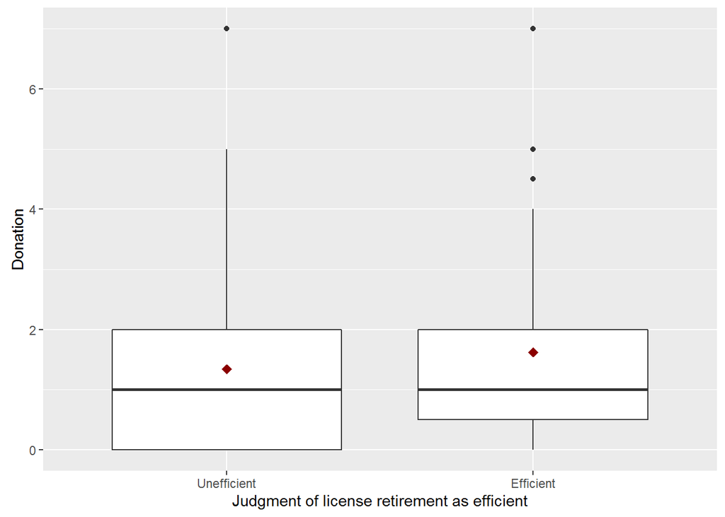

```
##
##  Welch Two Sample t-test
##
## data:  df$Donation by df$retireEffD
## t = -1.6958, df = 278.81, p-value = 0.09104
## alternative hypothesis: true difference in means is not equal to 0
## 95 percent confidence interval:
##  -0.60857476  0.04529092
## sample estimates:
## mean in group Unefficient   mean in group Efficient
##                  1.342358                  1.624000
```

```
##
##  Wilcoxon rank sum test with continuity correction
##
## data:  df$Donation by df$retireEffD
## W = 11934, p-value = 0.008118
## alternative hypothesis: true location shift is not equal to 0
```

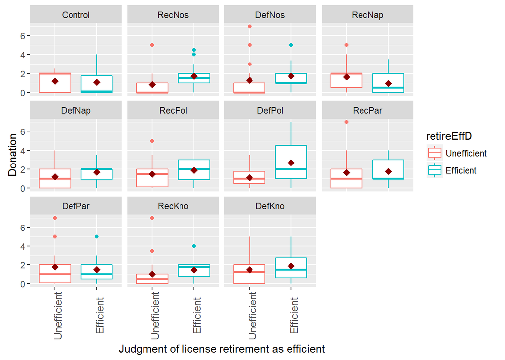

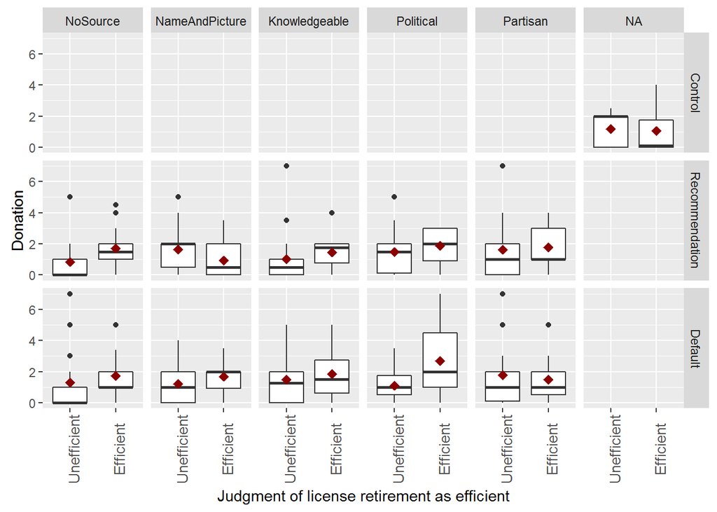

```
##
## Call:
## lm(formula = Donation ~ treatment * retireEffD, data = df)
##
## Residuals:
##    Min     1Q Median     3Q    Max
## -2.700 -1.175 -0.308  0.800  5.976
##
## Coefficients:
##                                     Estimate Std. Error t value Pr(>|t|)
## (Intercept)                          1.17500    0.34595   3.396 0.000765
## treatmentRecNos                     -0.33382    0.51037  -0.654 0.513511
## treatmentDefNos                      0.13300    0.46413   0.287 0.774632
## treatmentRecNap                      0.46389    0.50265   0.923 0.356734
## treatmentDefNap                      0.02500    0.48338   0.052 0.958784
## treatmentRecPol                      0.30227    0.47799   0.632 0.527574
## treatmentDefPol                     -0.06974    0.49564  -0.141 0.888191
## treatmentRecPar                      0.46786    0.48338   0.968 0.333807
## treatmentDefPar                      0.59167    0.48338   1.224 0.221814
## treatmentRecKno                     -0.15119    0.48338  -0.313 0.754647
## treatmentDefKno                      0.30833    0.46841   0.658 0.510833
## retireEffDEfficient                 -0.12045    0.58075  -0.207 0.835816
## treatmentRecNos:retireEffDEfficient  0.99356    0.80563   1.233 0.218346
## treatmentDefNos:retireEffDEfficient  0.55690    0.83604   0.666 0.505802
## treatmentRecNap:retireEffDEfficient -0.57843    0.79361  -0.729 0.466600
## treatmentDefNap:retireEffDEfficient  0.60379    0.80667   0.748 0.454693
## treatmentRecPol:retireEffDEfficient  0.51318    0.82791   0.620 0.535779
## treatmentDefPol:retireEffDEfficient  1.71519    0.83822   2.046 0.041521
## treatmentRecPar:retireEffDEfficient  0.25538    0.84688   0.302 0.763185
## treatmentDefPar:retireEffDEfficient -0.14621    0.79710  -0.183 0.854573
## treatmentRecKno:retireEffDEfficient  0.56331    0.80667   0.698 0.485468
## treatmentDefKno:retireEffDEfficient  0.49712    0.82241   0.604 0.545947
##
## (Intercept)                         ***
## treatmentRecNos
## treatmentDefNos
## treatmentRecNap
## treatmentDefNap
## treatmentRecPol
## treatmentDefPol
## treatmentRecPar
## treatmentDefPar
## treatmentRecKno
## treatmentDefKno
## retireEffDEfficient
## treatmentRecNos:retireEffDEfficient
## treatmentDefNos:retireEffDEfficient
## treatmentRecNap:retireEffDEfficient
## treatmentDefNap:retireEffDEfficient
## treatmentRecPol:retireEffDEfficient
## treatmentDefPol:retireEffDEfficient *
## treatmentRecPar:retireEffDEfficient
## treatmentDefPar:retireEffDEfficient
## treatmentRecKno:retireEffDEfficient
## treatmentDefKno:retireEffDEfficient
## ---
## Signif. codes:  0 '***' 0.001 '**' 0.01 '*' 0.05 '.' 0.1 ' ' 1
##
## Residual standard error: 1.547 on 332 degrees of freedom
## Multiple R-squared:  0.05624,    Adjusted R-squared:  -0.003453
## F-statistic: 0.9422 on 21 and 332 DF,  p-value: 0.5364
```

## … moral duty protect the climate

```
##
## No moral duty    Moral duty
##           136           218
```

```
##
##                 Control RecNos DefNos RecNap DefNap RecPol DefPol RecPar
##   No moral duty      11     13     14     19     16      5      7     12
##   Moral duty         20     18     20     14     17     27     22     18
##
##                 DefPar RecKno DefKno
##   No moral duty     10     17     12
##   Moral duty        24     16     22
```

```
##
##  Pearson's Chi-squared test
##
## data:  table(df$moralD, df$treatment)
## X-squared = 20.174, df = 10, p-value = 0.02765
```

```
##
## Call:
## glm(formula = moralD ~ treatment, family = "binomial", data = df)
##
## Deviance Residuals:
##     Min       1Q   Median       3Q      Max
## -1.9268  -1.2033   0.7433   1.0108   1.3095
##
## Coefficients:
##                  Estimate Std. Error z value Pr(>|z|)
## (Intercept)      0.597837   0.375379   1.593   0.1112
## treatmentRecNos -0.272415   0.522865  -0.521   0.6024
## treatmentDefNos -0.241162   0.512189  -0.471   0.6378
## treatmentRecNap -0.903219   0.514752  -1.755   0.0793 .
## treatmentDefNap -0.537212   0.512087  -1.049   0.2941
## treatmentRecPol  1.088562   0.614773   1.771   0.0766 .
## treatmentDefPol  0.547295   0.573777   0.954   0.3402
## treatmentRecPar -0.192372   0.528959  -0.364   0.7161
## treatmentDefPar  0.277632   0.531578   0.522   0.6015
## treatmentRecKno -0.658462   0.512087  -1.286   0.1985
## treatmentDefKno  0.008299   0.519324   0.016   0.9873
## ---
## Signif. codes:  0 '***' 0.001 '**' 0.01 '*' 0.05 '.' 0.1 ' ' 1
##
## (Dispersion parameter for binomial family taken to be 1)
##
##     Null deviance: 471.58  on 353  degrees of freedom
## Residual deviance: 450.50  on 343  degrees of freedom
## AIC: 472.5
##
## Number of Fisher Scoring iterations: 4
```

*Moral duty to protect climate is significantly different in treatments.*

## Average donation moral duty differences (by treatment)

```
## group: No moral duty
##   vars   n mean   sd median trimmed  mad min max range skew kurtosis   se
## 1    1 136  0.9 1.07    0.5    0.77 0.74   0   5     5 1.27     1.74 0.09
## --------------------------------------------------------
## group: Moral duty
##   vars   n mean   sd median trimmed  mad min max range skew kurtosis   se
## 1    1 218 1.78 1.69    1.5    1.54 1.48   0   7     7 1.15     1.12 0.11
```

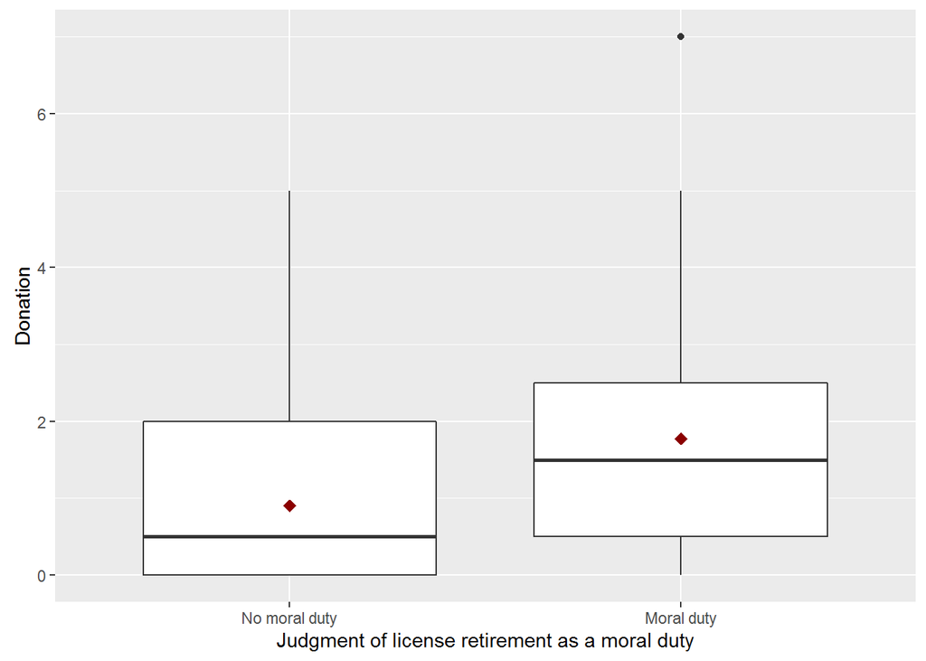

```
##
##  Welch Two Sample t-test
##
## data:  df$Donation by df$moralD
## t = -5.9481, df = 351.88, p-value = 6.548e-09
## alternative hypothesis: true difference in means is not equal to 0
## 95 percent confidence interval:
##  -1.1643716 -0.5857093
## sample estimates:
## mean in group No moral duty    mean in group Moral duty
##                   0.9029412                   1.7779817
```

```
##
##  Wilcoxon rank sum test with continuity correction
##
## data:  df$Donation by df$moralD
## W = 10152, p-value = 3.236e-07
## alternative hypothesis: true location shift is not equal to 0
```

*The significant differences are not really dependable, since moral duty correlates with treatments.*

```
##
## Call:
## lm(formula = Donation ~ treatment, data = df)
##
## Residuals:
##     Min      1Q  Median      3Q     Max
## -1.6833 -1.2121 -0.3485  0.7431  5.8152
##
## Coefficients:
##                 Estimate Std. Error t value Pr(>|t|)
## (Intercept)      1.13226    0.27915   4.056 6.18e-05 ***
## treatmentRecNos  0.10323    0.39478   0.261    0.794
## treatmentDefNos  0.29127    0.38597   0.755    0.451
## treatmentRecNap  0.18895    0.38875   0.486    0.627
## treatmentDefNap  0.24350    0.38875   0.626    0.531
## treatmentRecPol  0.46774    0.39168   1.194    0.233
## treatmentDefPol  0.52291    0.40153   1.302    0.194
## treatmentRecPar  0.55108    0.39805   1.384    0.167
## treatmentDefPar  0.53245    0.38597   1.380    0.169
## treatmentRecKno  0.05259    0.38875   0.135    0.892
## treatmentDefKno  0.46186    0.38597   1.197    0.232
## ---
## Signif. codes:  0 '***' 0.001 '**' 0.01 '*' 0.05 '.' 0.1 ' ' 1
##
## Residual standard error: 1.554 on 343 degrees of freedom
## Multiple R-squared:  0.01598,    Adjusted R-squared:  -0.01271
## F-statistic: 0.5569 on 10 and 343 DF,  p-value: 0.8486
```

```
##
## Call:
## lm(formula = Donation ~ RecvsDefD * Sourcetype, data = df)
##
## Residuals:
##     Min      1Q  Median      3Q     Max
## -1.6833 -1.2355 -0.3758  0.6788  5.8152
##
## Coefficients:
##                                       Estimate Std. Error t value Pr(>|t|)
## (Intercept)                            1.23548    0.28512   4.333 1.98e-05
## RecvsDefDDef                           0.18805    0.39423   0.477    0.634
## SourcetypeNameAndPicture               0.08573    0.39707   0.216    0.829
## SourcetypeKnowledgeable               -0.05064    0.39707  -0.128    0.899
## SourcetypePolitical                    0.36452    0.40006   0.911    0.363
## SourcetypePartisan                     0.44785    0.40657   1.102    0.272
## RecvsDefDDef:SourcetypeNameAndPicture -0.13350    0.55511  -0.240    0.810
## RecvsDefDDef:SourcetypeKnowledgeable   0.22122    0.55309   0.400    0.689
## RecvsDefDDef:SourcetypePolitical      -0.13287    0.56663  -0.234    0.815
## RecvsDefDDef:SourcetypePartisan       -0.20667    0.55995  -0.369    0.712
##
## (Intercept)                           ***
## RecvsDefDDef
## SourcetypeNameAndPicture
## SourcetypeKnowledgeable
## SourcetypePolitical
## SourcetypePartisan
## RecvsDefDDef:SourcetypeNameAndPicture
## RecvsDefDDef:SourcetypeKnowledgeable
## RecvsDefDDef:SourcetypePolitical
## RecvsDefDDef:SourcetypePartisan
## ---
## Signif. codes:  0 '***' 0.001 '**' 0.01 '*' 0.05 '.' 0.1 ' ' 1
##
## Residual standard error: 1.587 on 313 degrees of freedom
##   (31 observations deleted due to missingness)
## Multiple R-squared:  0.01276,    Adjusted R-squared:  -0.01562
## F-statistic: 0.4496 on 9 and 313 DF,  p-value: 0.9071
```

```
##
## Call:
## lm(formula = Donation ~ treatment + moralD, data = df)
##
## Residuals:
##     Min      1Q  Median      3Q     Max
## -2.0301 -0.9534 -0.2645  0.9668  5.3686
##
## Coefficients:
##                  Estimate Std. Error t value Pr(>|t|)
## (Intercept)        0.5730     0.2905   1.972   0.0494 *
## treatmentRecNos    0.1592     0.3811   0.418   0.6765
## treatmentDefNos    0.3406     0.3726   0.914   0.3612
## treatmentRecNap    0.3805     0.3770   1.009   0.3135
## treatmentDefNap    0.3562     0.3758   0.948   0.3438
## treatmentRecPol    0.2956     0.3794   0.779   0.4365
## treatmentDefPol    0.4246     0.3879   1.094   0.2745
## treatmentRecPar    0.5902     0.3842   1.536   0.1254
## treatmentDefPar    0.4798     0.3726   1.288   0.1987
## treatmentRecKno    0.1916     0.3761   0.509   0.6108
## treatmentDefKno    0.4602     0.3724   1.236   0.2174
## moralDMoral duty   0.8669     0.1688   5.137  4.7e-07 ***
## ---
## Signif. codes:  0 '***' 0.001 '**' 0.01 '*' 0.05 '.' 0.1 ' ' 1
##
## Residual standard error: 1.5 on 342 degrees of freedom
## Multiple R-squared:  0.08647,    Adjusted R-squared:  0.05708
## F-statistic: 2.943 on 11 and 342 DF,  p-value: 0.0009758
```

```
##
## Call:
## lm(formula = Donation ~ RecvsDefD * NosvsSomeD + moralD, data = df)
##
## Residuals:
##     Min      1Q  Median      3Q     Max
## -1.8850 -0.9087 -0.3850  1.0228  5.2027
##
## Coefficients:
##                                    Estimate Std. Error t value Pr(>|t|)
## (Intercept)                          0.7084     0.2908   2.436   0.0154
## RecvsDefDDef                         0.1812     0.3770   0.480   0.6312
## NosvsSomeDSome Source                0.2003     0.3039   0.659   0.5102
## moralDMoral duty                     0.9078     0.1738   5.222 3.21e-07
## RecvsDefDDef:NosvsSomeDSome Source  -0.1127     0.4219  -0.267   0.7896
##
## (Intercept)                        *
## RecvsDefDDef
## NosvsSomeDSome Source
## moralDMoral duty                   ***
## RecvsDefDDef:NosvsSomeDSome Source
## ---
## Signif. codes:  0 '***' 0.001 '**' 0.01 '*' 0.05 '.' 0.1 ' ' 1
##
## Residual standard error: 1.518 on 318 degrees of freedom
##   (31 observations deleted due to missingness)
## Multiple R-squared:  0.08267,    Adjusted R-squared:  0.07113
## F-statistic: 7.164 on 4 and 318 DF,  p-value: 1.557e-05
```

*When controlling for treatments, moral duty is a significant positive predictor for the Donation amount. Feeling morally obliged to contribute to climate protection raises the Donation by 0.87 ???, when controlling for treatments.*

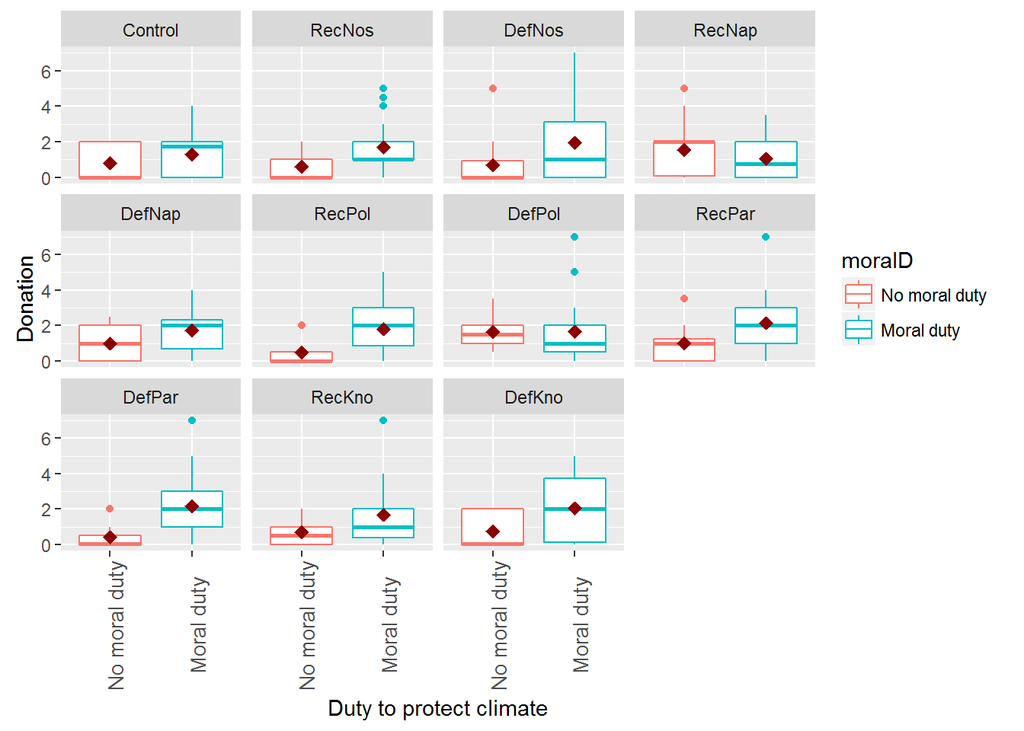

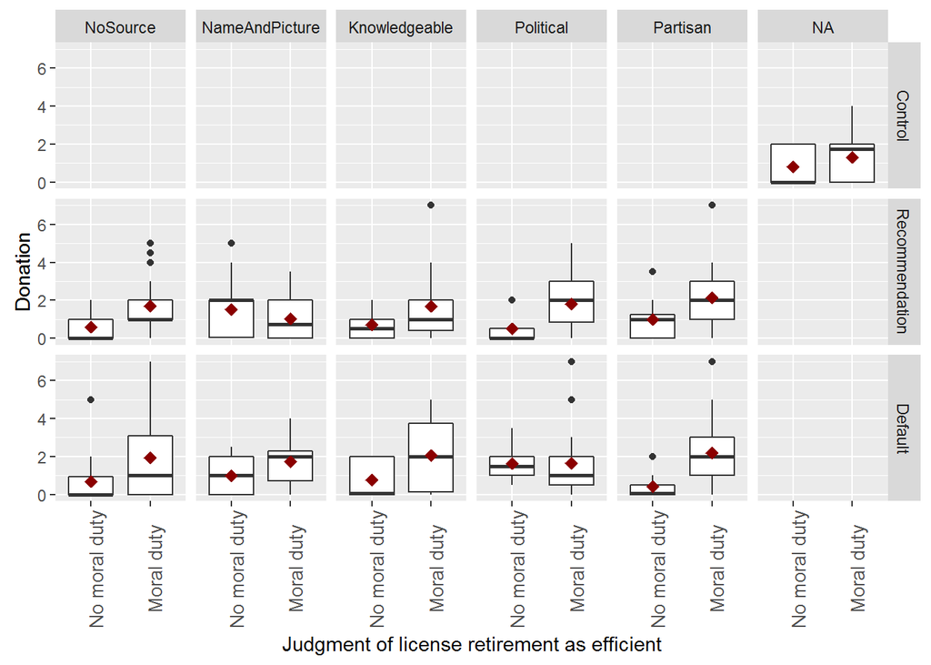

## … income

```
##
## Call:
## lm(formula = Donation ~ treatment + income, data = df)
##
## Residuals:
##     Min      1Q  Median      3Q     Max
## -2.2841 -1.2204 -0.3455  0.7513  5.5815
##
## Coefficients:
##                   Estimate Std. Error t value Pr(>|t|)
## (Intercept)      0.9322687  0.2970041   3.139  0.00185 **
## treatmentRecNos  0.1259023  0.3853424   0.327  0.74408
## treatmentDefNos  0.3240266  0.3770174   0.859  0.39072
## treatmentRecNap  0.1849262  0.3853627   0.480  0.63163
## treatmentDefNap  0.2388851  0.3821894   0.625  0.53237
## treatmentRecPol  0.4969523  0.3851522   1.290  0.19786
## treatmentDefPol  0.4949507  0.3920420   1.262  0.20766
## treatmentRecPar  0.5966247  0.3957567   1.508  0.13263
## treatmentDefPar  0.5748647  0.3792515   1.516  0.13053
## treatmentRecKno -0.0973724  0.3855650  -0.253  0.80078
## treatmentDefKno  0.2442904  0.3851104   0.634  0.52630
## income           0.0002704  0.0001603   1.687  0.09259 .
## ---
## Signif. codes:  0 '***' 0.001 '**' 0.01 '*' 0.05 '.' 0.1 ' ' 1
##
## Residual standard error: 1.516 on 330 degrees of freedom
##   (12 observations deleted due to missingness)
## Multiple R-squared:  0.03034,    Adjusted R-squared:  -0.001986
## F-statistic: 0.9385 on 11 and 330 DF,  p-value: 0.5033
```

```
##
## Call:
## glm(formula = Donated ~ treatment + income, family = "binomial",
##     data = df)
##
## Deviance Residuals:
##     Min       1Q   Median       3Q      Max
## -1.8760  -1.3180   0.7453   0.8836   1.1293
##
## Coefficients:
##                   Estimate Std. Error z value Pr(>|z|)
## (Intercept)      3.157e-01  4.040e-01   0.781   0.4346
## treatmentRecNos  2.735e-01  5.232e-01   0.523   0.6012
## treatmentDefNos -2.061e-01  5.013e-01  -0.411   0.6811
## treatmentRecNap  4.177e-01  5.296e-01   0.789   0.4304
## treatmentDefNap  6.136e-01  5.359e-01   1.145   0.2523
## treatmentRecPol  9.072e-01  5.631e-01   1.611   0.1072
## treatmentDefPol  1.242e+00  6.121e-01   2.029   0.0425 *
## treatmentRecPar  5.924e-01  5.552e-01   1.067   0.2860
## treatmentDefPar  8.144e-01  5.455e-01   1.493   0.1354
## treatmentRecKno  4.180e-01  5.300e-01   0.789   0.4302
## treatmentDefKno  1.342e-01  5.181e-01   0.259   0.7956
## income           1.317e-05  2.376e-04   0.055   0.9558
## ---
## Signif. codes:  0 '***' 0.001 '**' 0.01 '*' 0.05 '.' 0.1 ' ' 1
##
## (Dispersion parameter for binomial family taken to be 1)
##
##     Null deviance: 428.11  on 341  degrees of freedom
## Residual deviance: 416.72  on 330  degrees of freedom
##   (12 observations deleted due to missingness)
## AIC: 440.72
##
## Number of Fisher Scoring iterations: 4
```

## Fractions of participants donating: Pol vs Knowledge

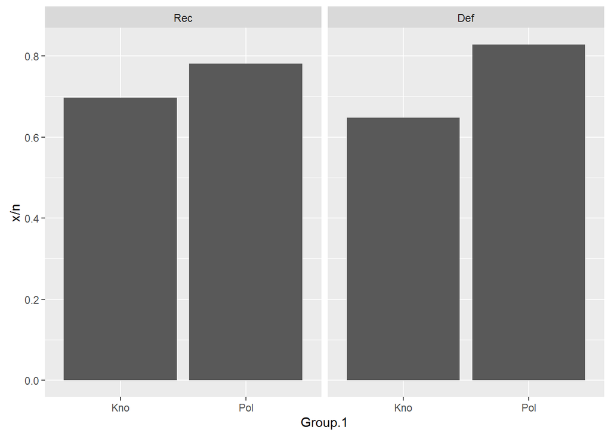

```
##
## Call:
## glm(formula = Donated ~ RecvsDefD * KnovsPol, family = "binomial",
##     data = df)
##
## Deviance Residuals:
##     Min       1Q   Median       3Q      Max
## -1.8750  -1.4432   0.7026   0.8497   0.9331
##
## Coefficients:
##                          Estimate Std. Error z value Pr(>|z|)
## (Intercept)                0.8329     0.3788   2.199   0.0279 *
## RecvsDefDDef              -0.2268     0.5218  -0.435   0.6638
## KnovsPolPol                0.4401     0.5713   0.770   0.4411
## RecvsDefDDef:KnovsPolPol   0.5224     0.8347   0.626   0.5314
## ---
## Signif. codes:  0 '***' 0.001 '**' 0.01 '*' 0.05 '.' 0.1 ' ' 1
##
## (Dispersion parameter for binomial family taken to be 1)
##
##     Null deviance: 148.19  on 127  degrees of freedom
## Residual deviance: 144.92  on 124  degrees of freedom
##   (226 observations deleted due to missingness)
## AIC: 152.92
##
## Number of Fisher Scoring iterations: 4
```

# Disaggregated reactance scores (4 categories)

```
##
## Call:
## lm(formula = Donation ~ treatment + reactance1d + reactance2d +
##     reactance3d + reactance4d + reactance5d + reactance6d + reactance7d +
##     reactance8d + reactance9d + reactance10d + reactance11d,
##     data = df)
##
## Residuals:
##     Min      1Q  Median      3Q     Max
## -2.2724 -1.1005 -0.3714  0.7278  5.4969
##
## Coefficients:
##                 Estimate Std. Error t value Pr(>|t|)
## (Intercept)      0.94095    0.41826   2.250   0.0251 *
## treatmentRecNos -0.01447    0.39937  -0.036   0.9711
## treatmentDefNos  0.30470    0.39995   0.762   0.4467
## treatmentRecNap  0.23667    0.39417   0.600   0.5486
## treatmentDefNap  0.29119    0.39780   0.732   0.4647
## treatmentRecPol  0.53650    0.39592   1.355   0.1763
## treatmentDefPol  0.59156    0.41045   1.441   0.1505
## treatmentRecPar  0.67007    0.40505   1.654   0.0990 .
## treatmentDefPar  0.65041    0.39493   1.647   0.1005
## treatmentRecKno  0.16741    0.39261   0.426   0.6701
## treatmentDefKno  0.54693    0.39752   1.376   0.1698
## reactance1d      0.30306    0.33080   0.916   0.3603
## reactance2d     -0.26364    0.38994  -0.676   0.4994
## reactance3d      0.42694    0.18495   2.308   0.0216 *
## reactance4d     -0.23381    0.20820  -1.123   0.2622
## reactance5d     -0.17338    0.20522  -0.845   0.3988
## reactance6d     -0.36983    0.33829  -1.093   0.2751
## reactance7d     -0.02145    0.17365  -0.124   0.9018
## reactance8d     -0.03521    0.18275  -0.193   0.8473
## reactance9d      0.19499    0.20745   0.940   0.3479
## reactance10d    -0.56481    0.33056  -1.709   0.0885 .
## reactance11d     0.76201    0.45047   1.692   0.0917 .
## ---
## Signif. codes:  0 '***' 0.001 '**' 0.01 '*' 0.05 '.' 0.1 ' ' 1
##
## Residual standard error: 1.549 on 332 degrees of freedom
## Multiple R-squared:  0.05384,    Adjusted R-squared:  -0.00601
## F-statistic: 0.8996 on 21 and 332 DF,  p-value: 0.592
```

```
##
## Call:
## lm(formula = Donation ~ treatment + as.factor(EmotionResp) +
##     as.factor(ReactCompl) + as.factor(ResistInfl) + as.factor(ReactAdv),
##     data = df)
##
## Residuals:
##     Min      1Q  Median      3Q     Max
## -2.5051 -1.1476 -0.3594  0.7243  5.3430
##
## Coefficients:
##                          Estimate Std. Error t value Pr(>|t|)
## (Intercept)              0.736099   0.453194   1.624   0.1053
## treatmentRecNos         -0.005423   0.399003  -0.014   0.9892
## treatmentDefNos          0.395710   0.402113   0.984   0.3258
## treatmentRecNap          0.235680   0.391344   0.602   0.5474
## treatmentDefNap          0.319443   0.397975   0.803   0.4227
## treatmentRecPol          0.533913   0.397358   1.344   0.1800
## treatmentDefPol          0.683147   0.407705   1.676   0.0948 .
## treatmentRecPar          0.581785   0.404362   1.439   0.1512
## treatmentDefPar          0.657105   0.392813   1.673   0.0953 .
## treatmentRecKno          0.133091   0.391121   0.340   0.7339
## treatmentDefKno          0.547243   0.399653   1.369   0.1718
## as.factor(EmotionResp)1  0.632542   0.397026   1.593   0.1121
## as.factor(EmotionResp)2  0.907914   0.406789   2.232   0.0263 *
## as.factor(EmotionResp)3  0.377753   0.512237   0.737   0.4614
## as.factor(ReactCompl)1   0.211673   0.204646   1.034   0.3017
## as.factor(ReactCompl)2   0.008047   0.250036   0.032   0.9743
## as.factor(ReactCompl)3   0.032521   0.381965   0.085   0.9322
## as.factor(ResistInfl)1  -0.352749   0.436930  -0.807   0.4201
## as.factor(ResistInfl)2  -0.449347   0.457319  -0.983   0.3265
## as.factor(ResistInfl)3  -0.781631   0.590293  -1.324   0.1864
## as.factor(ReactAdv)1    -0.265075   0.208132  -1.274   0.2037
## as.factor(ReactAdv)2     0.826840   0.527648   1.567   0.1181
## ---
## Signif. codes:  0 '***' 0.001 '**' 0.01 '*' 0.05 '.' 0.1 ' ' 1
##
## Residual standard error: 1.548 on 332 degrees of freedom
## Multiple R-squared:  0.05534,    Adjusted R-squared:  -0.004409
## F-statistic: 0.9262 on 21 and 332 DF,  p-value: 0.5571
```

*No significant effects of interest. Partly counter-intuitive.*

# Exclude observations with demandEffectD == 1

```
##
##     Control RecNos DefNos RecNap DefNap RecPol DefPol RecPar DefPar RecKno
##   0       5      2      8      4      8      4      7      6      8      5
##   1       5      4      9     13      6      8      7     11      6      8
##   2      16     16     10      9     16     15      9     10     11     10
##   3       4      8      4      3      2      2      4      2      4      7
##   4       1      1      3      4      1      3      2      1      5      3
##
##     DefKno
##   0      7
##   1      6
##   2      9
##   3     10
##   4      2
```

```
##
##  Pearson's Chi-squared test with simulated p-value (based on 2000
##  replicates)
##
## data:  table(df$demandEffect, df$treatment)
## X-squared = 46.611, df = NA, p-value = 0.2199
```

```
## group: 0
##   vars  n mean  sd median trimmed  mad min max range skew kurtosis   se
## 1    1 64 0.93 1.3    0.5     0.7 0.74   0   7     7 2.19     6.39 0.16
## --------------------------------------------------------
## group: 1
##   vars  n mean   sd median trimmed  mad min max range skew kurtosis   se
## 1    1 83 1.55 1.51      1    1.34 1.48   0   7     7 1.31      2.2 0.17
## --------------------------------------------------------
## group: 2
##   vars   n mean   sd median trimmed  mad min max range skew kurtosis   se
## 1    1 131 1.52 1.55      1    1.28 1.48   0   7     7 1.35     2.05 0.14
## --------------------------------------------------------
## group: 3
##   vars  n mean  sd median trimmed  mad min max range skew kurtosis   se
## 1    1 50 1.56 1.7      1    1.29 1.48   0   7     7 1.16     0.79 0.24
## --------------------------------------------------------
## group: 4
##   vars  n mean  sd median trimmed  mad min max range skew kurtosis   se
## 1    1 26 1.77 1.7      2    1.64 1.85   0   5     5 0.71     -0.6 0.33
```

```
##
##  Kruskal-Wallis rank sum test
##
## data:  df$Donation by df$demandEffect
## Kruskal-Wallis chi-squared = 11.166, df = 4, p-value = 0.02476
```

```
##
##                0  1  2  3  4
##   Not donated 28 19 38 16  8
##   Donated     36 64 93 34 18
```

```
##
##  Pearson's Chi-squared test
##
## data:  table(df$Donated, df$demandEffect)
## X-squared = 7.7038, df = 4, p-value = 0.1031
```

```
##
## Call:
## glm(formula = Donated ~ treatment + demandEffectD, family = "binomial",
##     data = df)
##
## Deviance Residuals:
##     Min       1Q   Median       3Q      Max
## -1.8763  -1.3193   0.7313   0.8531   1.1324
##
## Coefficients:
##                     Estimate Std. Error z value Pr(>|z|)
## (Intercept)          0.32765    0.36696   0.893   0.3719
## treatmentRecNos      0.27420    0.52421   0.523   0.6009
## treatmentDefNos     -0.20703    0.50070  -0.413   0.6793
## treatmentRecNap      0.50819    0.52553   0.967   0.3335
## treatmentDefNap      0.65444    0.53448   1.224   0.2208
## treatmentRecPol      0.94748    0.56155   1.687   0.0916 .
## treatmentDefPol      1.24383    0.61183   2.033   0.0421 *
## treatmentRecPar      0.68534    0.55068   1.245   0.2133
## treatmentDefPar      0.85467    0.54484   1.569   0.1167
## treatmentRecKno      0.50945    0.52693   0.967   0.3336
## treatmentDefKno      0.28336    0.51416   0.551   0.5816
## demandEffectDDemEff -0.01378    0.28906  -0.048   0.9620
## ---
## Signif. codes:  0 '***' 0.001 '**' 0.01 '*' 0.05 '.' 0.1 ' ' 1
##
## (Dispersion parameter for binomial family taken to be 1)
##
##     Null deviance: 437.13  on 353  degrees of freedom
## Residual deviance: 425.47  on 342  degrees of freedom
## AIC: 449.47
##
## Number of Fisher Scoring iterations: 4
```

```
##
## Call:
## lm(formula = Donation ~ treatment + demandEffectD, data = df)
##
## Residuals:
##     Min      1Q  Median      3Q     Max
## -1.8643 -1.1637 -0.3692  0.7347  5.8951
##
## Coefficients:
##                     Estimate Std. Error t value Pr(>|t|)
## (Intercept)          1.08973    0.28083   3.880 0.000125 ***
## treatmentRecNos      0.06920    0.39529   0.175 0.861125
## treatmentDefNos      0.27951    0.38571   0.725 0.469148
## treatmentRecNap      0.17555    0.38852   0.452 0.651664
## treatmentDefNap      0.26206    0.38865   0.674 0.500587
## treatmentRecPol      0.46907    0.39131   1.199 0.231464
## treatmentDefPol      0.51089    0.40125   1.273 0.203797
## treatmentRecPar      0.56724    0.39787   1.426 0.154874
## treatmentDefPar      0.50518    0.38618   1.308 0.191706
## treatmentRecKno      0.01522    0.38946   0.039 0.968854
## treatmentDefKno      0.41133    0.38760   1.061 0.289337
## demandEffectDDemEff  0.26367    0.20493   1.287 0.199091
## ---
## Signif. codes:  0 '***' 0.001 '**' 0.01 '*' 0.05 '.' 0.1 ' ' 1
##
## Residual standard error: 1.553 on 342 degrees of freedom
## Multiple R-squared:  0.02072,    Adjusted R-squared:  -0.01078
## F-statistic: 0.6578 on 11 and 342 DF,  p-value: 0.7782
```

```
## group: Control
##   vars  n mean   sd median trimmed  mad min max range skew kurtosis   se
## 1    1 26 1.17 1.16   1.25    1.07 1.48   0   4     4 0.41    -0.84 0.23
## --------------------------------------------------------
## group: RecNos
##   vars  n mean   sd median trimmed  mad min max range skew kurtosis   se
## 1    1 22  1.1 1.36   0.75    0.88 1.11   0 4.5   4.5 1.09     0.11 0.29
## --------------------------------------------------------
## group: DefNos
##   vars  n mean   sd median trimmed  mad min max range skew kurtosis   se
## 1    1 27  1.5 2.16    0.7    1.15 1.04   0   7     7 1.42     0.75 0.42
## --------------------------------------------------------
## group: RecNap
##   vars  n mean   sd median trimmed  mad min max range skew kurtosis   se
## 1    1 26 1.14 1.33   0.75    0.94 1.11   0   5     5 1.15     0.86 0.26
## --------------------------------------------------------
## group: DefNap
##   vars  n mean   sd median trimmed  mad min max range skew kurtosis  se
## 1    1 30 1.43 1.11   1.75    1.35 1.11   0   4     4 0.26    -0.75 0.2
## --------------------------------------------------------
## group: RecPol
##   vars  n mean   sd median trimmed  mad min max range skew kurtosis   se
## 1    1 27 1.54 1.17    1.5    1.53 1.48   0 3.5   3.5 0.03    -1.44 0.23
## --------------------------------------------------------
## group: DefPol
##   vars  n mean  sd median trimmed  mad min max range skew kurtosis   se
## 1    1 23 1.65 1.7      1    1.37 1.48   0   7     7 1.55     2.16 0.35
## --------------------------------------------------------
## group: RecPar
##   vars  n mean   sd median trimmed  mad min max range skew kurtosis   se
## 1    1 27 1.65 1.74      1    1.46 1.48   0   7     7 1.13     0.98 0.33
## --------------------------------------------------------
## group: DefPar
##   vars  n mean   sd median trimmed  mad min max range skew kurtosis   se
## 1    1 25 1.54 1.67      1    1.27 1.48   0   7     7 1.64     2.57 0.33
## --------------------------------------------------------
## group: RecKno
##   vars  n mean   sd median trimmed  mad min max range skew kurtosis   se
## 1    1 23 1.31 1.55      1    1.03 1.48   0   7     7 2.14      5.3 0.32
## --------------------------------------------------------
## group: DefKno
##   vars  n mean   sd median trimmed  mad min max range skew kurtosis  se
## 1    1 22 1.16 1.43    0.5    0.92 0.74   0   5     5 1.07     0.32 0.3
```

```
##
##  Kruskal-Wallis rank sum test
##
## data:  dfnoDE$Donation and dfnoDE$treatment
## Kruskal-Wallis chi-squared = 7.3133, df = 10, p-value = 0.6956
```

```
##
## Call:
## lm(formula = Donation ~ treatment, data = dfnoDE)
##
## Residuals:
##     Min      1Q  Median      3Q     Max
## -1.6522 -1.1522 -0.4963  0.8269  5.6913
##
## Coefficients:
##                  Estimate Std. Error t value Pr(>|t|)
## (Intercept)      1.173077   0.297298   3.946 0.000102 ***
## treatmentRecNos -0.068531   0.439139  -0.156 0.876105
## treatmentDefNos  0.323219   0.416532   0.776 0.438449
## treatmentRecNap -0.034615   0.420443  -0.082 0.934445
## treatmentDefNap  0.256923   0.406187   0.633 0.527585
## treatmentRecPol  0.371368   0.416532   0.892 0.373426
## treatmentDefPol  0.479097   0.433937   1.104 0.270556
## treatmentRecPar  0.475071   0.416532   1.141 0.255084
## treatmentDefPar  0.370923   0.424627   0.874 0.383161
## treatmentRecKno  0.135619   0.433937   0.313 0.754881
## treatmentDefKno -0.009441   0.439139  -0.021 0.982865
## ---
## Signif. codes:  0 '***' 0.001 '**' 0.01 '*' 0.05 '.' 0.1 ' ' 1
##
## Residual standard error: 1.516 on 267 degrees of freedom
## Multiple R-squared:  0.01747,    Adjusted R-squared:  -0.01933
## F-statistic: 0.4748 on 10 and 267 DF,  p-value: 0.9056
```

```
##
## Call:
## glm(formula = Donated ~ treatment, family = "binomial", data = dfnoDE)
##
## Deviance Residuals:
##     Min       1Q   Median       3Q      Max
## -1.9145  -1.3116   0.7002   0.9854   1.0842
##
## Coefficients:
##                 Estimate Std. Error z value Pr(>|z|)
## (Intercept)      0.31015    0.39696   0.781   0.4346
## treatmentRecNos  0.05757    0.58789   0.098   0.9220
## treatmentDefNos -0.08701    0.55460  -0.157   0.8753
## treatmentRecNap  0.15985    0.56575   0.283   0.7775
## treatmentDefNap  0.87943    0.58644   1.500   0.1337
## treatmentRecPol  0.94261    0.60980   1.546   0.1222
## treatmentDefPol  1.24799    0.67839   1.840   0.0658 .
## treatmentRecPar  0.55484    0.57897   0.958   0.3379
## treatmentDefPar  1.34807    0.67468   1.998   0.0457 *
## treatmentRecKno  0.97078    0.64275   1.510   0.1310
## treatmentDefKno  0.05757    0.58789   0.098   0.9220
## ---
## Signif. codes:  0 '***' 0.001 '**' 0.01 '*' 0.05 '.' 0.1 ' ' 1
##
## (Dispersion parameter for binomial family taken to be 1)
##
##     Null deviance: 342.31  on 277  degrees of freedom
## Residual deviance: 328.04  on 267  degrees of freedom
## AIC: 350.04
##
## Number of Fisher Scoring iterations: 4
```

# Change dependent variable Donation to log(Donation+1)

# Double Hurdle Model

*My justification of a double-hurdle model (an extension of the Tobit Model) is that some subjects simply do not contribute to climate protection, they are zero-types. Contrary to Tobit (and p Tobit) models, a double Hurdle Model allows to specify the zero types via a set of subject characteristics, i.e. via independent variables. This is a generalization of the p tobit model, since it allows to vary the p parameter according to subject characteristics. I have to theoretically argue which characteristics are relevant (predict) whether a subject is a zero type and whether the treatment is important for this. Afterwards, the model predicts the amount subjects contribute.* > Source: Engel 2014

```
##
## Call:
## mhurdle(formula = Donation ~ moralD + retireEffD + NosvsSomeD +
##     RecvsDefD | NosvsSomeD + RecvsDefD + belief + gender | 0,
##     data = dfsub)
##
## Frequency of 0:  0.29688
##
## Coefficients :
##                           Estimate Std. Error t-value  Pr(>|t|)
## h1.(Intercept)           -0.215673   0.206372 -1.0451 0.2959906
## h1.moralDMoral duty       0.513003   0.155403  3.3011 0.0009630 ***
## h1.retireEffDEfficient    0.581440   0.170344  3.4133 0.0006418 ***
## h1.NosvsSomeDSome Source  0.367262   0.185555  1.9793 0.0477859 *
## h1.RecvsDefDDef          -0.033698   0.153902 -0.2190 0.8266844
## h2.(Intercept)           -0.356651   0.151085 -2.3606 0.0182450 *
## h2.NosvsSomeDSome Source -0.174946   0.117336 -1.4910 0.1359659
## h2.RecvsDefDDef           0.089233   0.087665  1.0179 0.3087327
## h2.belief                 0.389188   0.042861  9.0802 < 2.2e-16 ***
## h2.genderWeiblich         0.142373   0.091951  1.5484 0.1215375
## sd                        0.656601   0.030952 21.2132 < 2.2e-16 ***
## ---
## Signif. codes:  0 '***' 0.001 '**' 0.01 '*' 0.05 '.' 0.1 ' ' 1
##
## Log-Likelihood: -508.84 on 11 Df
##
## R^2 :
##  Coefficient of determination : 0.31387
##  Likelihood ratio index       : 0.094522
```

```
##
##      0  1  2  3  4
##   0 13  7  4  3  2
##   1  8 21  8  1  2
##   2  6 24 22 13  1
##   3 11 30 38 61 24
##   4  2  4  9 16 20
```

```
##
## Call:
## glm(formula = Donated ~ moralD + retireEffD + NosvsSomeD * RecvsDefD *
##     Reactance, family = "binomial", data = dfsub)
##
## Deviance Residuals:
##     Min       1Q   Median       3Q      Max
## -2.3432  -1.0774   0.6082   0.8293   1.4927
##
## Coefficients:
##                                              Estimate Std. Error z value
## (Intercept)                                   -3.4639     1.7125  -2.023
## moralDMoral duty                               0.8887     0.2664   3.336
## retireEffDEfficient                            1.0587     0.3059   3.461
## NosvsSomeDSome Source                          4.0594     1.7738   2.289
## RecvsDefDDef                                   2.9683     1.8659   1.591
## Reactance                                      0.7711     0.4061   1.899
## NosvsSomeDSome Source:RecvsDefDDef            -3.9997     2.0059  -1.994
## NosvsSomeDSome Source:Reactance               -0.8688     0.4195  -2.071
## RecvsDefDDef:Reactance                        -0.8078     0.4340  -1.861
## NosvsSomeDSome Source:RecvsDefDDef:Reactance   1.0515     0.4599   2.286
##                                              Pr(>|z|)
## (Intercept)                                  0.043107 *
## moralDMoral duty                             0.000850 ***
## retireEffDEfficient                          0.000539 ***
## NosvsSomeDSome Source                        0.022103 *
## RecvsDefDDef                                 0.111658
## Reactance                                    0.057626 .
## NosvsSomeDSome Source:RecvsDefDDef           0.046160 *
## NosvsSomeDSome Source:Reactance              0.038371 *
## RecvsDefDDef:Reactance                       0.062701 .
## NosvsSomeDSome Source:RecvsDefDDef:Reactance 0.022248 *
## ---
## Signif. codes:  0 '***' 0.001 '**' 0.01 '*' 0.05 '.' 0.1 ' ' 1
##
## (Dispersion parameter for binomial family taken to be 1)
##
##     Null deviance: 389.24  on 319  degrees of freedom
## Residual deviance: 350.04  on 310  degrees of freedom
##   (30 observations deleted due to missingness)
## AIC: 370.04
##
## Number of Fisher Scoring iterations: 5
```

```
##
## Call:
## lm(formula = Donation ~ NosvsSomeD + RecvsDefD + belief + gender,
##     data = dfsub)
##
## Residuals:
##     Min      1Q  Median      3Q     Max
## -3.8302 -0.8784 -0.0402  0.7205  5.7114
##
## Coefficients:
##                       Estimate Std. Error t value Pr(>|t|)
## (Intercept)           -0.28924    0.23919  -1.209   0.2275
## NosvsSomeDSome Source -0.06009    0.18704  -0.321   0.7482
## RecvsDefDDef           0.17736    0.14902   1.190   0.2349
## belief                 0.70023    0.07208   9.714   <2e-16 ***
## genderWeiblich         0.50097    0.15211   3.293   0.0011 **
## ---
## Signif. codes:  0 '***' 0.001 '**' 0.01 '*' 0.05 '.' 0.1 ' ' 1
##
## Residual standard error: 1.332 on 315 degrees of freedom
##   (30 observations deleted due to missingness)
## Multiple R-squared:  0.2584, Adjusted R-squared:  0.249
## F-statistic: 27.44 on 4 and 315 DF,  p-value: < 2.2e-16
```

```
##
## Call:
## mhurdle(formula = Donation ~ moralD + retireEffD + NosvsSomeD *
##     RecvsDefD * Reactance + gender + age + income | NosvsSomeD +
##     RecvsDefD + belief + gender + age + income | 0, data = dfsub,
##     dist = "l")
##
## Frequency of 0:  0.30744
##
## Coefficients :
##                                                    Estimate  Std. Error
## h1.(Intercept)                                  -2.1126e+00  1.0664e+00
## h1.moralDMoral duty                              5.4245e-01  1.6571e-01
## h1.retireEffDEfficient                           6.1068e-01  1.7996e-01
## h1.NosvsSomeDSome Source                         2.4963e+00  1.0179e+00
## h1.RecvsDefDDef                                  1.7091e+00  1.0843e+00
## h1.Reactance                                     4.5228e-01  2.2643e-01
## h1.genderWeiblich                                2.9813e-01  1.6771e-01
## h1.age                                          -6.6484e-03  1.8311e-02
## h1.income                                        1.0369e-04  2.0969e-04
## h1.NosvsSomeDSome Source:RecvsDefDDef           -2.4724e+00  1.1728e+00
## h1.NosvsSomeDSome Source:Reactance              -5.4531e-01  2.3638e-01
## h1.RecvsDefDDef:Reactance                       -4.5555e-01  2.4612e-01
## h1.NosvsSomeDSome Source:RecvsDefDDef:Reactance  6.3729e-01  2.6325e-01
## h2.(Intercept)                                  -6.3890e-01  3.0923e-01
## h2.NosvsSomeDSome Source                        -1.7905e-01  1.1894e-01
## h2.RecvsDefDDef                                  4.6116e-02  9.2134e-02
## h2.belief                                        3.8419e-01  4.4664e-02
## h2.genderWeiblich                                1.9388e-01  9.5882e-02
## h2.age                                           7.9411e-03  1.0740e-02
## h2.income                                        1.1253e-04  9.0244e-05
## sd                                               6.5574e-01  3.1696e-02
##                                                 t-value  Pr(>|t|)
## h1.(Intercept)                                  -1.9810 0.0475862 *
## h1.moralDMoral duty                              3.2734 0.0010626 **
## h1.retireEffDEfficient                           3.3934 0.0006903 ***
## h1.NosvsSomeDSome Source                         2.4525 0.0141852 *
## h1.RecvsDefDDef                                  1.5763 0.1149593
## h1.Reactance                                     1.9974 0.0457809 *
## h1.genderWeiblich                                1.7776 0.0754654 .
## h1.age                                          -0.3631 0.7165457
## h1.income                                        0.4945 0.6209571
## h1.NosvsSomeDSome Source:RecvsDefDDef           -2.1082 0.0350146 *
## h1.NosvsSomeDSome Source:Reactance              -2.3069 0.0210582 *
## h1.RecvsDefDDef:Reactance                       -1.8509 0.0641795 .
## h1.NosvsSomeDSome Source:RecvsDefDDef:Reactance  2.4209 0.0154841 *
## h2.(Intercept)                                  -2.0661 0.0388161 *
## h2.NosvsSomeDSome Source                        -1.5054 0.1322126
## h2.RecvsDefDDef                                  0.5005 0.6167000
## h2.belief                                        8.6018 < 2.2e-16 ***
## h2.genderWeiblich                                2.0221 0.0431691 *
## h2.age                                           0.7394 0.4596472
## h2.income                                        1.2469 0.2124325
## sd                                              20.6882 < 2.2e-16 ***
## ---
## Signif. codes:  0 '***' 0.001 '**' 0.01 '*' 0.05 '.' 0.1 ' ' 1
##
## Log-Likelihood: -481.12 on 21 Df
##
## R^2 :
##  Coefficient of determination : 0.3122
##  Likelihood ratio index       : 0.10987
```

```
##
## Call:
## mhurdle(formula = Donation ~ moralD + retireEffD + NosvsSomeD *
##     RecvsDefD * Reactance + gender | belief + gender + age +
##     income | 0, data = dfsub, dist = "l")
##
## Frequency of 0:  0.30744
##
## Coefficients :
##                                                    Estimate  Std. Error
## h1.(Intercept)                                  -2.1912e+00  9.7317e-01
## h1.moralDMoral duty                              5.4708e-01  1.6281e-01
## h1.retireEffDEfficient                           6.1983e-01  1.7954e-01
## h1.NosvsSomeDSome Source                         2.4678e+00  1.0130e+00
## h1.RecvsDefDDef                                  1.6491e+00  1.0753e+00
## h1.Reactance                                     4.4518e-01  2.2482e-01
## h1.genderWeiblich                                2.9652e-01  1.6507e-01
## h1.NosvsSomeDSome Source:RecvsDefDDef           -2.4181e+00  1.1654e+00
## h1.NosvsSomeDSome Source:Reactance              -5.3639e-01  2.3469e-01
## h1.RecvsDefDDef:Reactance                       -4.4395e-01  2.4405e-01
## h1.NosvsSomeDSome Source:RecvsDefDDef:Reactance  6.2622e-01  2.6135e-01
## h2.(Intercept)                                  -8.1492e-01  2.8868e-01
## h2.belief                                        3.7778e-01  4.4718e-02
## h2.genderWeiblich                                1.9305e-01  9.6425e-02
## h2.age                                           1.0806e-02  1.0513e-02
## h2.income                                        1.0432e-04  9.0405e-05
## sd                                               6.5948e-01  3.1877e-02
##                                                 t-value  Pr(>|t|)
## h1.(Intercept)                                  -2.2516 0.0243461 *
## h1.moralDMoral duty                              3.3603 0.0007787 ***
## h1.retireEffDEfficient                           3.4522 0.0005560 ***
## h1.NosvsSomeDSome Source                         2.4360 0.0148504 *
## h1.RecvsDefDDef                                  1.5336 0.1251174
## h1.Reactance                                     1.9802 0.0476838 *
## h1.genderWeiblich                                1.7963 0.0724447 .
## h1.NosvsSomeDSome Source:RecvsDefDDef           -2.0750 0.0379888 *
## h1.NosvsSomeDSome Source:Reactance              -2.2856 0.0222794 *
## h1.RecvsDefDDef:Reactance                       -1.8191 0.0688947 .
## h1.NosvsSomeDSome Source:RecvsDefDDef:Reactance  2.3961 0.0165707 *
## h2.(Intercept)                                  -2.8229 0.0047593 **
## h2.belief                                        8.4482 < 2.2e-16 ***
## h2.genderWeiblich                                2.0021 0.0452753 *
## h2.age                                           1.0278 0.3040231
## h2.income                                        1.1539 0.2485449
## sd                                              20.6882 < 2.2e-16 ***
## ---
## Signif. codes:  0 '***' 0.001 '**' 0.01 '*' 0.05 '.' 0.1 ' ' 1
##
## Log-Likelihood: -482.48 on 17 Df
##
## R^2 :
##  Coefficient of determination : 0.29975
##  Likelihood ratio index       : 0.10735
```

*Potentially interesting story. Is it possible to link regression to explain believes with regression to explain donations, of which belief is one independent variable? Probably overly complex.* *Of course here I will also have to check whether the assumptions for these models are met.*

> A Hurdle Model, according to Carlevaro, Croissant, Hoareau, consists of up to three hurdles. * Hurdle 1 (the good selection mechanism) models the household decision of selecting or not selecting the good we consider as a relevant consumption good, complying with household’s ethical, psychological and social convictions and habits. [Do I want to buy it/ Do I need it?] * Hurdle 2 (the desired consumption mechanism) models the household decision of consuming or not consuming the selected good, given its actual economic conditions. [Can I buy it/ Can I afford it?] * Hurdle 3 (the purchasing mechanism) models the household decision to purchase or not to purchase the good during the survey period over which expenditure data are collected [Do I buy it/ Am I observed buying it?]

> The formula should have three parts on the right-hand side specifying, in the first part, the good selection equation covariates, in the second part, the desired consumption equation covariates and, in the third part, the purchasing equation covariates. “If one wants that zeros only arise from the selection mechanism, one has to switch the dist argument to”l“, so that a log-normal distribution is introduced.” - Based on the text by Engel, I think that their hurdle model includes all observations in the second model, so that there based on the IVs the subjects also have the “chance” to not contribute anything (based on the second set of IVs) - there seem to be two hurdles were subjects can “fall”. I think I introduce this by specifying dist = “n”, which changes the significance of many parameters. If I change it to dist = “t”, this seems to be similar to dist = “l”

> Interdependence between these censoring mechanisms is modelled by assuming a possible correlation between the random disturbances in the model relations.

# Checking model assumptions for models that I will use

## Check for heteroskedasticity

```
##
## Call:
## glm(formula = Donated ~ moralD + retireEffD + NosvsSomeD * RecvsDefD *
##     Reactance + gender + age + income, family = "binomial", data = dfsub)
##
## Deviance Residuals:
##     Min       1Q   Median       3Q      Max
## -2.4362  -1.0464   0.5644   0.8261   1.6531
##
## Coefficients:
##                                                Estimate Std. Error z value
## (Intercept)                                  -3.7716211  1.9236909  -1.961
## moralDMoral duty                              0.8844947  0.2775073   3.187
## retireEffDEfficient                           1.0477886  0.3142118   3.335
## NosvsSomeDSome Source                         4.3776566  1.8557899   2.359
## RecvsDefDDef                                  3.0565106  1.9481267   1.569
## Reactance                                     0.8068520  0.4264531   1.892
## genderWeiblich                                0.4970249  0.2807032   1.771
## age                                          -0.0100297  0.0306265  -0.327
## income                                        0.0001995  0.0003715   0.537
## NosvsSomeDSome Source:RecvsDefDDef           -4.3826833  2.0939127  -2.093
## NosvsSomeDSome Source:Reactance              -0.9645683  0.4422565  -2.181
## RecvsDefDDef:Reactance                       -0.8126441  0.4549217  -1.786
## NosvsSomeDSome Source:RecvsDefDDef:Reactance  1.1287227  0.4827428   2.338
##                                              Pr(>|z|)
## (Intercept)                                  0.049924 *
## moralDMoral duty                             0.001436 **
## retireEffDEfficient                          0.000854 ***
## NosvsSomeDSome Source                        0.018328 *
## RecvsDefDDef                                 0.116660
## Reactance                                    0.058490 .
## genderWeiblich                               0.076620 .
## age                                          0.743302
## income                                       0.591249
## NosvsSomeDSome Source:RecvsDefDDef           0.036344 *
## NosvsSomeDSome Source:Reactance              0.029182 *
## RecvsDefDDef:Reactance                       0.074044 .
## NosvsSomeDSome Source:RecvsDefDDef:Reactance 0.019380 *
## ---
## Signif. codes:  0 '***' 0.001 '**' 0.01 '*' 0.05 '.' 0.1 ' ' 1
##
## (Dispersion parameter for binomial family taken to be 1)
##
##     Null deviance: 381.33  on 308  degrees of freedom
## Residual deviance: 335.58  on 296  degrees of freedom
##   (41 observations deleted due to missingness)
## AIC: 361.58
##
## Number of Fisher Scoring iterations: 5
```

```
##
## Call:
## lm(formula = Donation ~ moralD + retireEffD + NosvsSomeD * RecvsDefD *
##     Reactance + gender + age + income + belief, data = dfsub)
##
## Residuals:
##     Min      1Q  Median      3Q     Max
## -3.5063 -0.8713 -0.0445  0.6352  5.2800
##
## Coefficients:
##                                                Estimate Std. Error t value
## (Intercept)                                  -1.5967946  0.8599852  -1.857
## moralDMoral duty                              0.5917591  0.1598248   3.703
## retireEffDEfficient                           0.3061296  0.1594651   1.920
## NosvsSomeDSome Source                         1.1436603  0.8007956   1.428
## RecvsDefDDef                                  1.6961684  0.8895098   1.907
## Reactance                                     0.1456606  0.1597220   0.912
## genderWeiblich                                0.4208477  0.1589363   2.648
## age                                          -0.0036912  0.0172919  -0.213
## income                                        0.0002849  0.0001663   1.713
## belief                                        0.6680868  0.0742260   9.001
## NosvsSomeDSome Source:RecvsDefDDef           -2.1177863  0.9756060  -2.171
## NosvsSomeDSome Source:Reactance              -0.2154448  0.1708546  -1.261
## RecvsDefDDef:Reactance                       -0.2421547  0.1863902  -1.299
## NosvsSomeDSome Source:RecvsDefDDef:Reactance  0.3356681  0.2039386   1.646
##                                              Pr(>|t|)
## (Intercept)                                  0.064341 .
## moralDMoral duty                             0.000255 ***
## retireEffDEfficient                          0.055857 .
## NosvsSomeDSome Source                        0.154305
## RecvsDefDDef                                 0.057510 .
## Reactance                                    0.362533
## genderWeiblich                               0.008535 **
## age                                          0.831112
## income                                       0.087689 .
## belief                                        < 2e-16 ***
## NosvsSomeDSome Source:RecvsDefDDef           0.030748 *
## NosvsSomeDSome Source:Reactance              0.208311
## RecvsDefDDef:Reactance                       0.194896
## NosvsSomeDSome Source:RecvsDefDDef:Reactance 0.100844
## ---
## Signif. codes:  0 '***' 0.001 '**' 0.01 '*' 0.05 '.' 0.1 ' ' 1
##
## Residual standard error: 1.284 on 295 degrees of freedom
##   (41 observations deleted due to missingness)
## Multiple R-squared:  0.3289, Adjusted R-squared:  0.2993
## F-statistic: 11.12 on 13 and 295 DF,  p-value: < 2.2e-16
```

```
##
##  Vuong Test (nested)
##
## data:  hurdlecorr-hurdle
## chisq = 0.50958, df = 1, p-value = 0.4753
```

```
##         Estimate Std. Error   t-value  Pr(>|t|)
## corr12 0.2202295  0.2541788 0.8664353 0.3862515
```

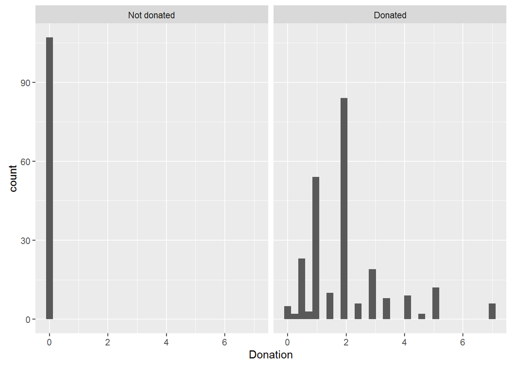

> With the Breusch-Pagan test and the NCV test it is possible to test for heteroskedasticity and quantify it

```
##
##  studentized Breusch-Pagan test
##
## data:  lm
## BP = 3.01, df = 3, p-value = 0.3901
```

> In order to rectify Heteroskedasticity, one would need to rebuild the model with new predictors, or transform variables with, e.g., Box-Cox transformation. The latter procedure mathematically transforms a variable to make it approximate to a normal distribution. This can be done for the dependent variable (can also be applied to IVs). Can only be applied to values bigger than 0 (if there are many zeros, we can add a constant to the variable)

> I should just use heteroskedasticity-robust standard errors!

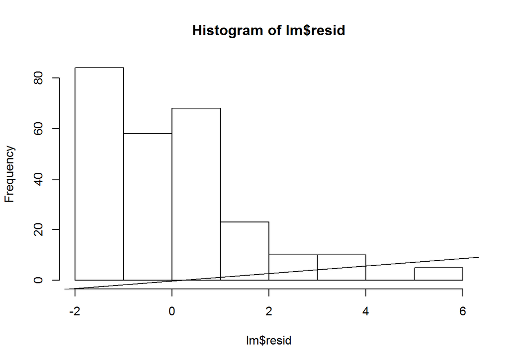

```
## [1] 1.293086
## attr(,"method")
## [1] "moment"
```

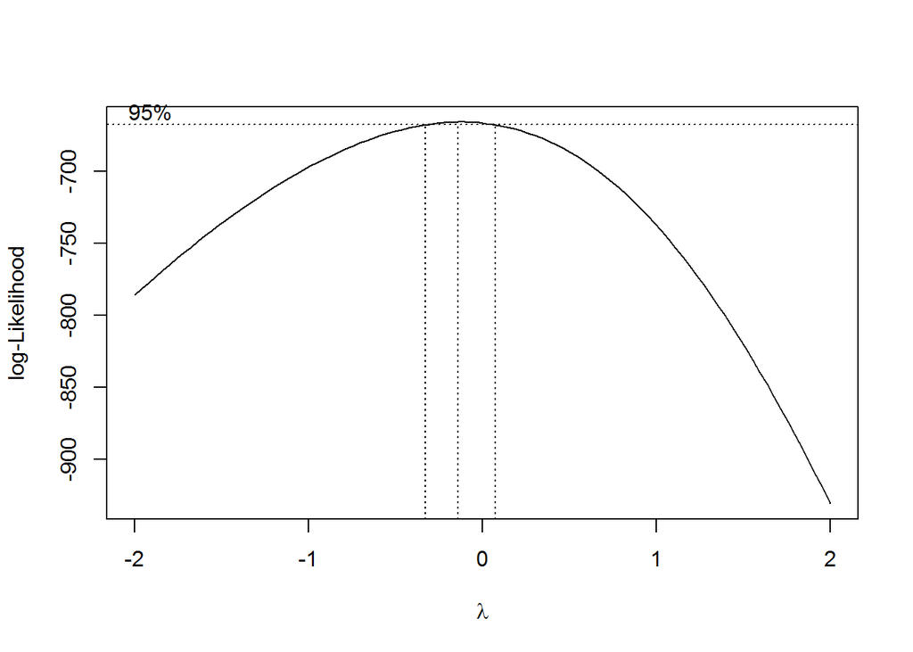

```
##              lamda       lik
##   [1,] -0.14141414 -665.7705
##   [2,] -0.10101010 -665.7794
##   [3,] -0.18181818 -665.9168
##   [4,] -0.06060606 -665.9472
##   [5,] -0.22222222 -666.2149
##   [6,] -0.02020202 -666.2773
##   [7,] -0.26262626 -666.6613
##   [8,]  0.02020202 -666.7733
##   [9,] -0.30303030 -667.2525
##  [10,]  0.06060606 -667.4385
##  [11,] -0.34343434 -667.9852
##  [12,]  0.10101010 -668.2764
##  [13,] -0.38383838 -668.8559
##  [14,]  0.14141414 -669.2904
```

[output cut: 86 more lines]

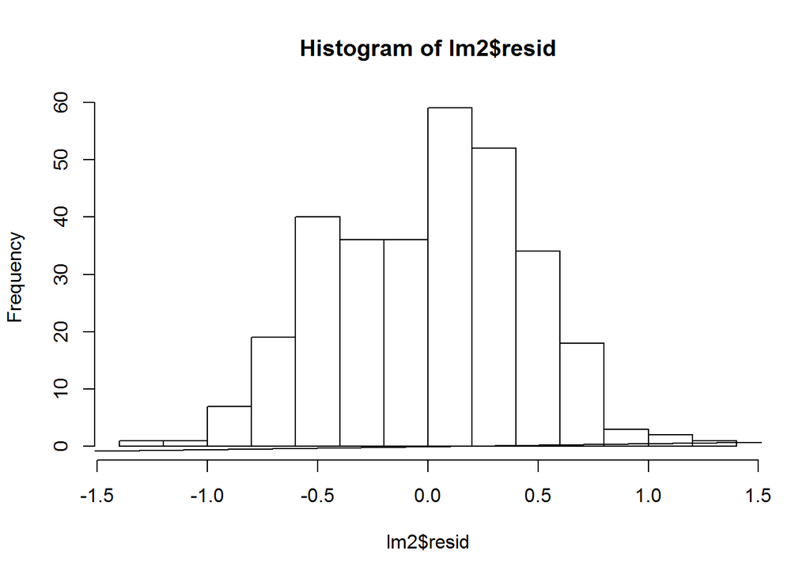

```
## [1] -0.09952942
## attr(,"method")
## [1] "moment"
```

```
##
##  studentized Breusch-Pagan test
##
## data:  lm2
## BP = 35.355, df = 13, p-value = 0.0007467
```